# Alcohol drinking

#### 2.4.2.4 Validation

## 2.5 Dominican Republic

### 2.5.1 Wave 1

#### 2.5.1.1 Study-specific variable description

| **Name** | `PALCNOW` | `PALCPAST` |
| --- | --- | --- |
| **Label** | `alcohol - units drunk per week now` `1 unit = a small glass of beer = a single measure of spirits = 1 glass of wine or sherry` `32 units = 1 bottle of spirits` | `alcohol - units drunk per week before age of 65 years` `1 unit = a small glass of beer = a single measure of spirits = 1 glass of wine or sherry` `32 units = 1 bottle of spirits` |
| **Table name** | `1066-DominicanRepublic-Baseline` | `1066-DominicanRepublic-Baseline` |
| **Categories** | `continuous` | `continuous` |
| **Missings** | `NA` | `NA` |
| **Description** |  |  |

PALCNOW

| Sample size | Missing values |
| --- | --- |
| 2011 | 15 |

Summary

| Min. | 1st Qu. | Median | Mean | 3rd Qu. | Max. | NA’s |
| --- | --- | --- | --- | --- | --- | --- |
| 0 | 0 | 0 | 9.713 | 0 | 400 | 15 |

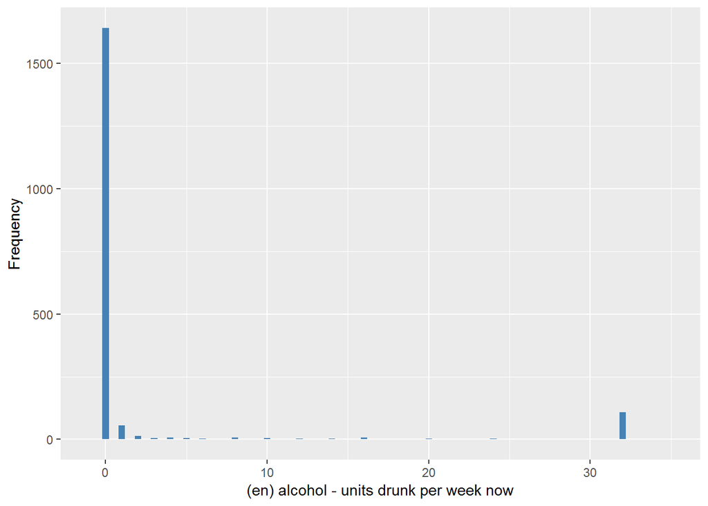

PALCPAST

| Sample size | Missing values |
| --- | --- |
| 2011 | 18 |

Summary

| Min. | 1st Qu. | Median | Mean | 3rd Qu. | Max. | NA’s |
| --- | --- | --- | --- | --- | --- | --- |
| 0 | 0 | 0 | 34.27 | 32 | 400 | 18 |

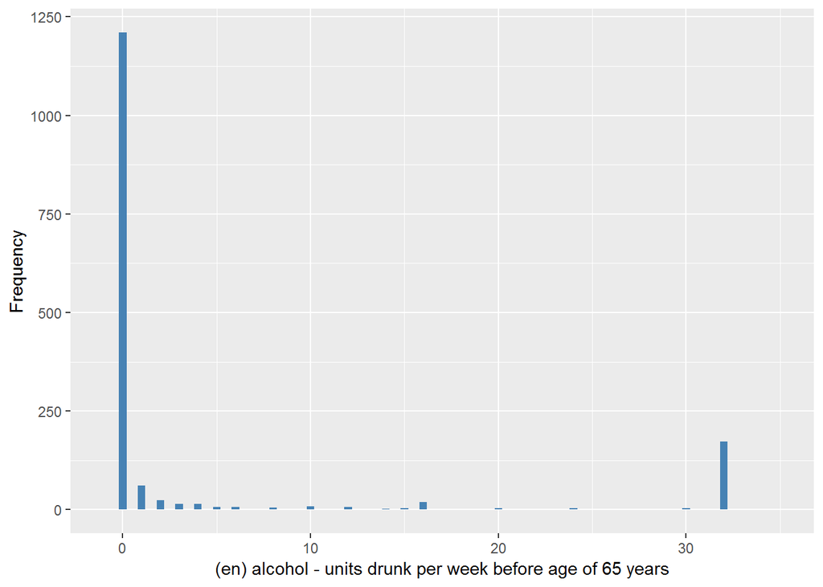

#### 2.5.1.2 Harmonisation algorithm

To compute `freq_oh` from the study-specific variable it has to be recoded as follows:

- `If PALCNOW=0 then 'drinking_frequency'=0`
- `if PALCNOW=1 or 2 then 'drinking_frequency'=1`
- `if PALCNOW>2 then 'drinking_frequency'=2`

To compute `past_oh` from the study-specific variable it has to be recoded as follows:

- `PALCPAST == 0 into 0`
- `PALCPAST > 0 into 1`
- `NA into 999`

**R script:**

```r
t1066_ds_DR_w1 <- tibble(id = t1066_DR_w1$id)
t1066_ds_DR_w1$freq_oh <- car::recode(t1066_DR_w1$PALCNOW, "0 = 0; c(1,2) = 1; 3:hi = 2; NA = 999")
t1066_ds_DR_w1$current_oh <- car::recode(t1066_ds_DR_w1$freq_oh, "2 = 1")
t1066_ds_DR_w1$past_oh <- car::recode(t1066_DR_w1$PALCPAST, "0 = 0; 1:hi = 1; NA = 999")
```

#### 2.5.1.3 Statistics of the new harmonized variable

Current alcohol drinker

| Sample size | Missing values |
| --- | --- |
| 2011 | 15 |

Category

|  | 0 | 1 |
| --- | --- | --- |
| Frequency | 1641.0 | 355.00 |
| Percentage | 81.6 | 17.65 |

Type of missing

|  | 991 | 992 | 993 | 994 | 995 | 996 | 997 | 998 | 999 | NA |
| --- | --- | --- | --- | --- | --- | --- | --- | --- | --- | --- |
| Frequency | 0 | 0 | 0 | 0 | 0 | 0 | 0 | 0 | 15.00 | 0 |
| Percentage | 0 | 0 | 0 | 0 | 0 | 0 | 0 | 0 | 0.75 | 0 |

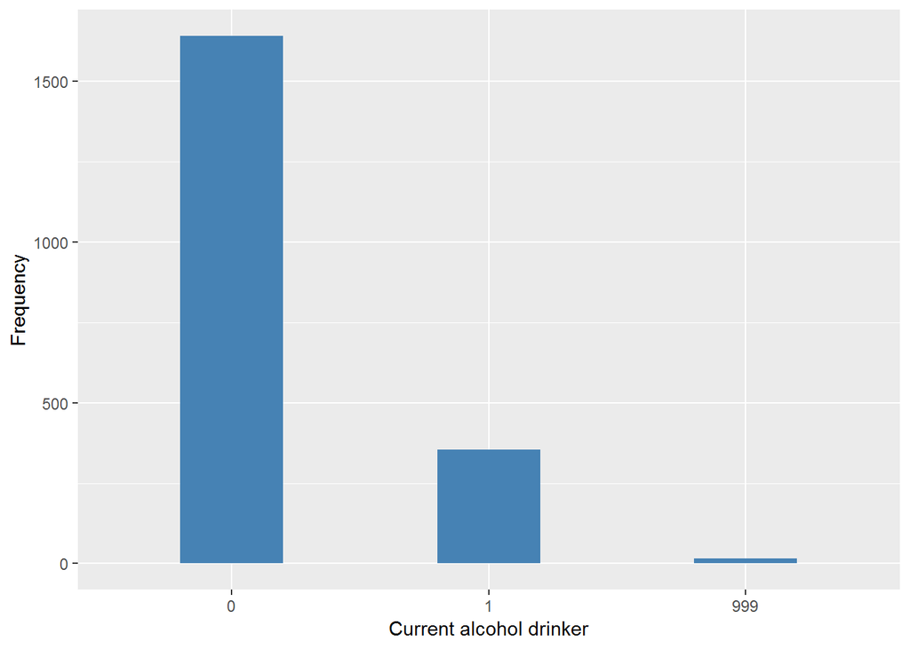

Frequency of alcohol drinking

| Sample size | Missing values |
| --- | --- |
| 2011 | 15 |

Category

|  | 0 | 1 | 2 |
| --- | --- | --- | --- |
| Frequency | 1641.0 | 69.00 | 286.00 |
| Percentage | 81.6 | 3.43 | 14.22 |

Type of missing

|  | 991 | 992 | 993 | 994 | 995 | 996 | 997 | 998 | 999 | NA |
| --- | --- | --- | --- | --- | --- | --- | --- | --- | --- | --- |
| Frequency | 0 | 0 | 0 | 0 | 0 | 0 | 0 | 0 | 15.00 | 0 |
| Percentage | 0 | 0 | 0 | 0 | 0 | 0 | 0 | 0 | 0.75 | 0 |

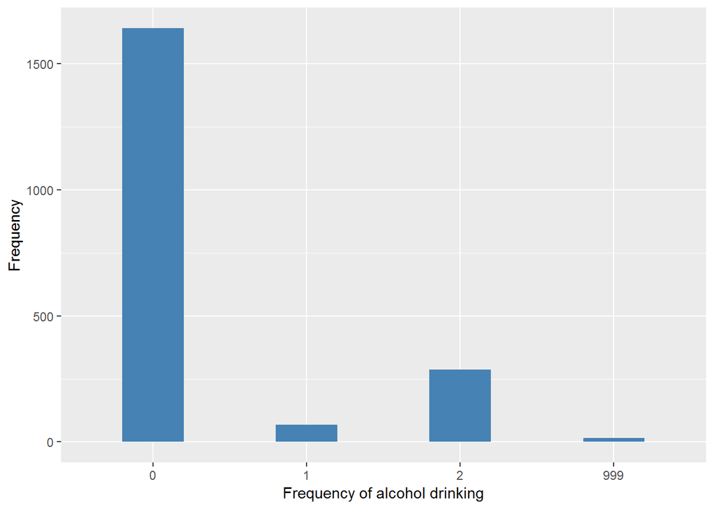

Past drinking

| Sample size | Missing values |
| --- | --- |
| 2011 | 18 |

Category

|  | 0 | 1 |
| --- | --- | --- |
| Frequency | 1210.00 | 783.00 |
| Percentage | 60.17 | 38.94 |

Type of missing

|  | 991 | 992 | 993 | 994 | 995 | 996 | 997 | 998 | 999 | NA |
| --- | --- | --- | --- | --- | --- | --- | --- | --- | --- | --- |
| Frequency | 0 | 0 | 0 | 0 | 0 | 0 | 0 | 0 | 18.0 | 0 |
| Percentage | 0 | 0 | 0 | 0 | 0 | 0 | 0 | 0 | 0.9 | 0 |

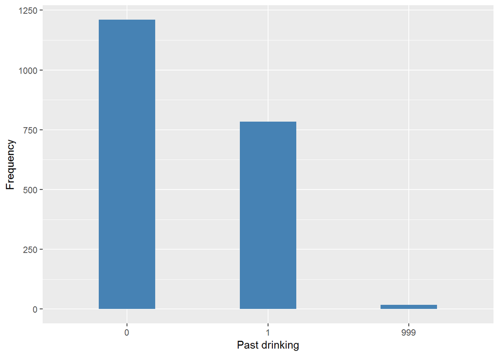

#### 2.5.1.4 Validation

### 2.5.2 Wave 2

#### 2.5.2.1 Study-specific variable description

| **Name** | `f_PALCPAST` |
| --- | --- |
| **Label** | `In the last week how much did you drink` `1 unit = a small glass of beer = a single measure of spirits = 1 glass of wine or sherry` `32 units = 1 bottle of spirits` |
| **Table name** | `1066-DominicanRepublic-Followup` |
| **Categories** | `continuous` |
| **Missings** | `NA` |
| **Description** |  |

f_PALCPAST

| Sample size | Missing values |
| --- | --- |
| 1197 | 24 |

Summary

| Min. | 1st Qu. | Median | Mean | 3rd Qu. | Max. | NA’s |
| --- | --- | --- | --- | --- | --- | --- |
| 0 | 0 | 0 | 1.303 | 0 | 128 | 24 |

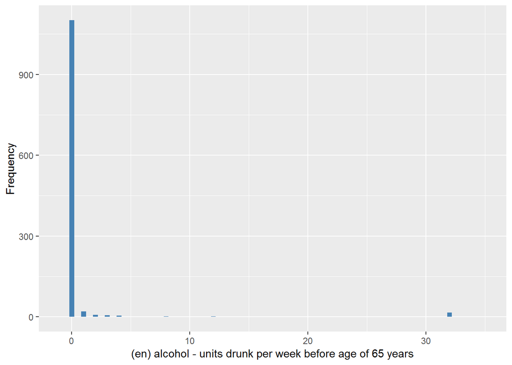

#### 2.5.2.2 Harmonisation algorithm

To compute `current_oh` from the study-specific variable it has to be recoded as follows:

- `f_PALCPAST == 0 into 0`
- `f_PALCPAST > 0 into 1`
- `NA into 999`

To compute `freq_oh` from the study-specific variable it has to be recoded as follows:

- `If f_PALCPAST=0 then 'drinking_frequency'=0`
- `if f_PALCPAST=1 or 2 then 'drinking_frequency'=1`
- `if f_PALCPAST>2 then 'drinking_frequency'=2`

To compute `past_oh` from the study-specific variable it has to be recoded as follows:

- `take from wave 1`

**R script:**

```r
t1066_ds_DR_w2 <- tibble(id = t1066_DR_w2$id)

t1066_ds_DR_w2$freq_oh <- car::recode(t1066_DR_w2$f_PALCPAST, "0 = 0; c(1,2) = 1; 3:hi = 2; NA = 999")
t1066_ds_DR_w2$current_oh <- car::recode(t1066_ds_DR_w2$freq_oh, "2 = 1")

t1066_DR_w2 <- left_join(t1066_DR_w2, t1066_ds_DR_w1, by = "id")
t1066_ds_DR_w2$past_oh <- t1066_DR_w2$past_oh
```

#### 2.5.2.3 Statistics of the new harmonized variable

Current alcohol drinker

| Sample size | Missing values |
| --- | --- |
| 1197 | 24 |

Category

|  | 0 | 1 |
| --- | --- | --- |
| Frequency | 1101.00 | 72.00 |
| Percentage | 91.98 | 6.02 |

Type of missing

|  | 991 | 992 | 993 | 994 | 995 | 996 | 997 | 998 | 999 | NA |
| --- | --- | --- | --- | --- | --- | --- | --- | --- | --- | --- |
| Frequency | 0 | 0 | 0 | 0 | 0 | 0 | 0 | 0 | 24.00 | 0 |
| Percentage | 0 | 0 | 0 | 0 | 0 | 0 | 0 | 0 | 2.01 | 0 |

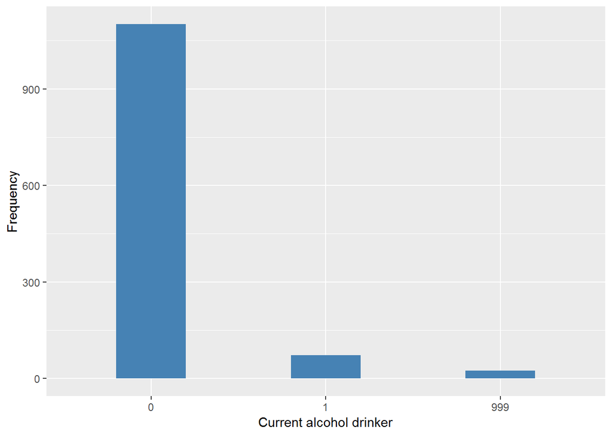

Frequency of alcohol drinking

| Sample size | Missing values |
| --- | --- |
| 1197 | 24 |

Category

|  | 0 | 1 | 2 |
| --- | --- | --- | --- |
| Frequency | 1101.00 | 28.00 | 44.00 |
| Percentage | 91.98 | 2.34 | 3.68 |

Type of missing

|  | 991 | 992 | 993 | 994 | 995 | 996 | 997 | 998 | 999 | NA |
| --- | --- | --- | --- | --- | --- | --- | --- | --- | --- | --- |
| Frequency | 0 | 0 | 0 | 0 | 0 | 0 | 0 | 0 | 24.00 | 0 |
| Percentage | 0 | 0 | 0 | 0 | 0 | 0 | 0 | 0 | 2.01 | 0 |

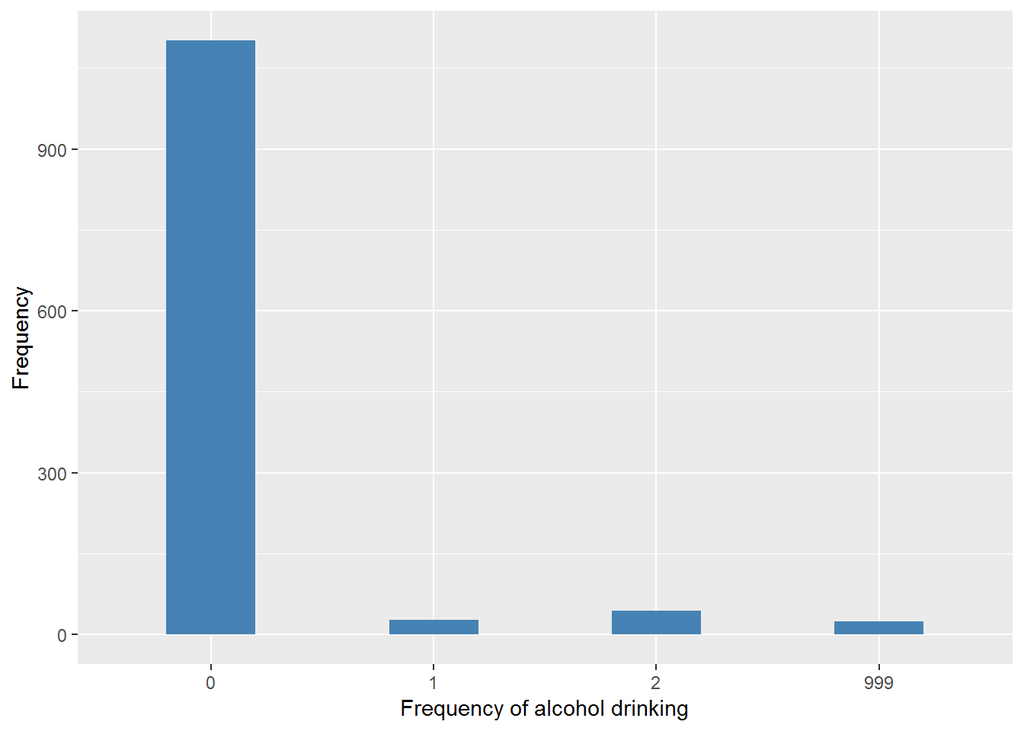

Past drinking

| Sample size | Missing values |
| --- | --- |
| 1197 | 11 |

Category

|  | 0 | 1 |
| --- | --- | --- |
| Frequency | 730.00 | 456.0 |
| Percentage | 60.99 | 38.1 |

Type of missing

|  | 991 | 992 | 993 | 994 | 995 | 996 | 997 | 998 | 999 | NA |
| --- | --- | --- | --- | --- | --- | --- | --- | --- | --- | --- |
| Frequency | 0 | 0 | 0 | 0 | 0 | 0 | 0 | 0 | 11.00 | 0 |
| Percentage | 0 | 0 | 0 | 0 | 0 | 0 | 0 | 0 | 0.92 | 0 |

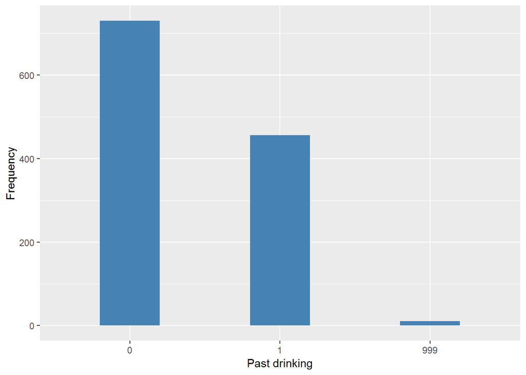

#### 2.5.2.4 Validation

## 2.6 Venezuela

### 2.6.1 Wave 1

#### 2.6.1.1 Study-specific variable description

| **Name** | `PALCNOW` | `PALCPAST` |
| --- | --- | --- |
| **Label** | `alcohol - units drunk per week now` `1 unit = a small glass of beer = a single measure of spirits = 1 glass of wine or sherry` `32 units = 1 bottle of spirits` | `alcohol - units drunk per week before age of 65 years` `1 unit = a small glass of beer = a single measure of spirits = 1 glass of wine or sherry` `32 units = 1 bottle of spirits` |
| **Table name** | `1066-Venezuela-Baseline` | `1066-Venezuela-Baseline` |
| **Categories** | `continuous` | `continuous` |
| **Missings** | `NA` | `NA` |
| **Description** |  |  |

PALCNOW

| Sample size | Missing values |
| --- | --- |
| 1965 | 803 |

Summary

| Min. | 1st Qu. | Median | Mean | 3rd Qu. | Max. | NA’s |
| --- | --- | --- | --- | --- | --- | --- |
| 0 | 0 | 0 | 1.949 | 2 | 50 | 803 |

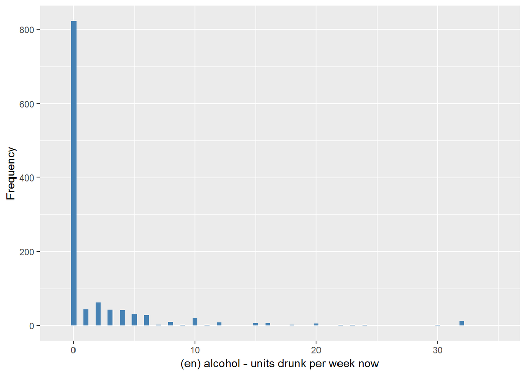

PALCPAST

| Sample size | Missing values |
| --- | --- |
| 1965 | 775 |

Summary

| Min. | 1st Qu. | Median | Mean | 3rd Qu. | Max. | NA’s |
| --- | --- | --- | --- | --- | --- | --- |
| 0 | 0 | 0 | 5.824 | 6 | 160 | 775 |

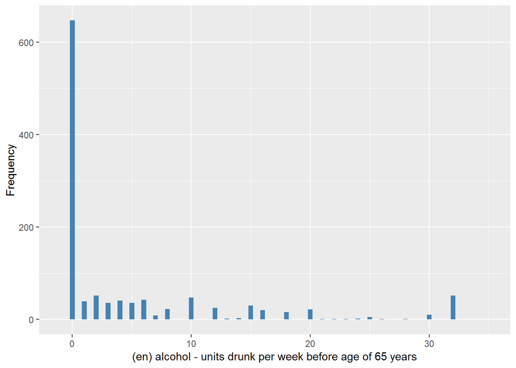

#### 2.6.1.2 Harmonisation algorithm

To compute `current_oh` from the study-specific variable it has to be recoded as follows:

- `PALCNOW == 0 into 0`
- `PALCNOW > 0 into 1`
- `NA into 999`

To compute `freq_oh` from the study-specific variable it has to be recoded as follows:

- `If PALCNOW=0 then 'drinking_frequency'=0`
- `if PALCNOW=1 or 2 then 'drinking_frequency'=1`
- `if PALCNOW>2 then 'drinking_frequency'=2`

To compute `past_oh` from the study-specific variable it has to be recoded as follows:

- `PALCPAST == 0 into 0`
- `PALCPAST > 0 into 1`
- `NA into 999`

**R script:**

```r
t1066_ds_Ven_w1 <- tibble(id = t1066_Ven_w1$id)
t1066_ds_Ven_w1$freq_oh <- car::recode(t1066_Ven_w1$PALCNOW, "0 = 0; c(1,2) = 1; 3:hi = 2; NA = 999")
t1066_ds_Ven_w1$current_oh <- car::recode(t1066_ds_Ven_w1$freq_oh, "2 = 1")
t1066_ds_Ven_w1$past_oh <- car::recode(t1066_Ven_w1$PALCPAST, "0 = 0; 1:hi = 1; NA = 999")
```

#### 2.6.1.3 Statistics of the new harmonized variable

Current alcohol drinker

| Sample size | Missing values |
| --- | --- |
| 1965 | 803 |

Category

|  | 0 | 1 |
| --- | --- | --- |
| Frequency | 823.00 | 339.00 |
| Percentage | 41.88 | 17.25 |

Type of missing

|  | 991 | 992 | 993 | 994 | 995 | 996 | 997 | 998 | 999 | NA |
| --- | --- | --- | --- | --- | --- | --- | --- | --- | --- | --- |
| Frequency | 0 | 0 | 0 | 0 | 0 | 0 | 0 | 0 | 803.00 | 0 |
| Percentage | 0 | 0 | 0 | 0 | 0 | 0 | 0 | 0 | 40.87 | 0 |

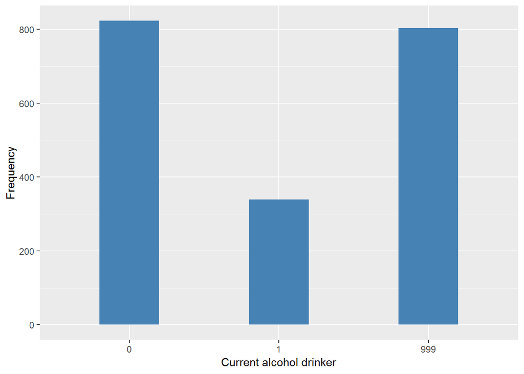

Frequency of alcohol drinking

| Sample size | Missing values |
| --- | --- |
| 1965 | 803 |

Category

|  | 0 | 1 | 2 |
| --- | --- | --- | --- |
| Frequency | 823.00 | 107.00 | 232.00 |
| Percentage | 41.88 | 5.45 | 11.81 |

Type of missing

|  | 991 | 992 | 993 | 994 | 995 | 996 | 997 | 998 | 999 | NA |
| --- | --- | --- | --- | --- | --- | --- | --- | --- | --- | --- |
| Frequency | 0 | 0 | 0 | 0 | 0 | 0 | 0 | 0 | 803.00 | 0 |
| Percentage | 0 | 0 | 0 | 0 | 0 | 0 | 0 | 0 | 40.87 | 0 |

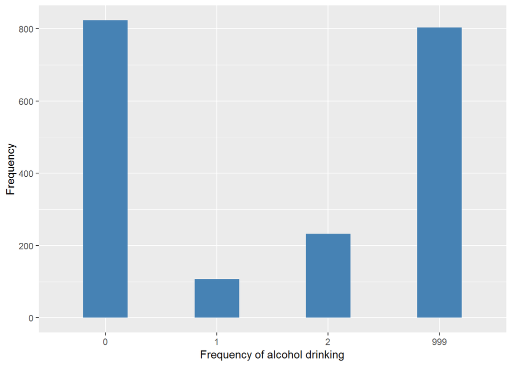

Past drinking

| Sample size | Missing values |
| --- | --- |
| 1965 | 775 |

Category

|  | 0 | 1 |
| --- | --- | --- |
| Frequency | 647.00 | 543.00 |
| Percentage | 32.93 | 27.63 |

Type of missing

|  | 991 | 992 | 993 | 994 | 995 | 996 | 997 | 998 | 999 | NA |
| --- | --- | --- | --- | --- | --- | --- | --- | --- | --- | --- |
| Frequency | 0 | 0 | 0 | 0 | 0 | 0 | 0 | 0 | 775.00 | 0 |
| Percentage | 0 | 0 | 0 | 0 | 0 | 0 | 0 | 0 | 39.44 | 0 |

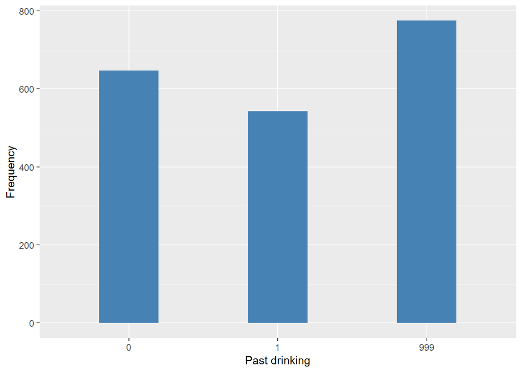

#### 2.6.1.4 Validation

### 2.6.2 Wave 2

#### 2.6.2.1 Study-specific variable description

| **Name** | `f_PALCPAST` |
| --- | --- |
| **Label** | `In the last week how much did you drink` `1 unit = a small glass of beer = a single measure of spirits = 1 glass of wine or sherry` `32 units = 1 bottle of spirits` |
| **Table name** | `1066-Venezuela-Followup` |
| **Categories** | `continuous` |
| **Missings** | `NA` |
| **Description** |  |

f_PALCPAST

| Sample size | Missing values |
| --- | --- |
| 1257 | 11 |

Summary

| Min. | 1st Qu. | Median | Mean | 3rd Qu. | Max. | NA’s |
| --- | --- | --- | --- | --- | --- | --- |
| 0 | 0 | 0 | 0.7665 | 0 | 48 | 11 |

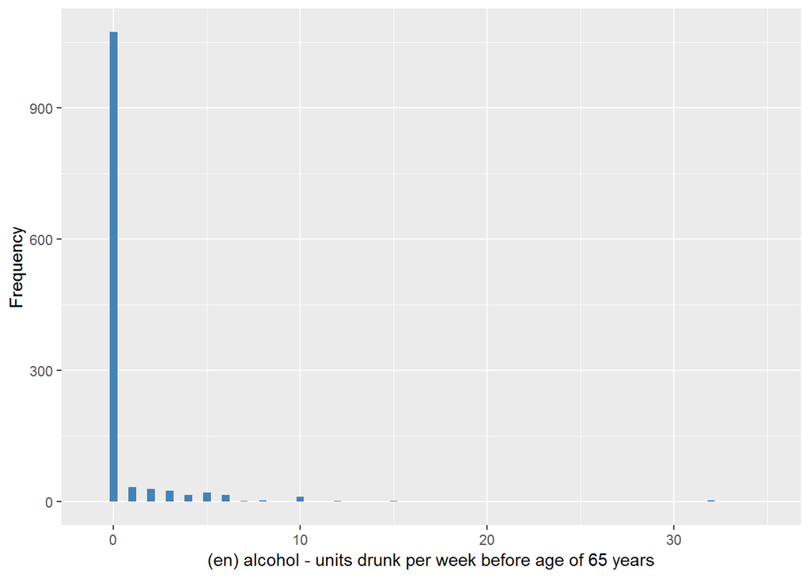

#### 2.6.2.2 Harmonisation algorithm

To compute `current_oh` from the study-specific variable it has to be recoded as follows:

- `f_PALCPAST == 0 into 0`
- `f_PALCPAST > 0 into 1`
- `NA into 999`

To compute `freq_oh` from the study-specific variable it has to be recoded as follows:

- `If f_PALCPAST=0 then 'drinking_frequency'=0`
- `if f_PALCPAST=1 or 2 then 'drinking_frequency'=1`
- `if f_PALCPAST>2 then 'drinking_frequency'=2`

To compute `past_oh` from the study-specific variable it has to be recoded as follows:

- `take from wave 1`

**R script:**

```r
t1066_ds_Ven_w2 <- tibble(id = t1066_Ven_w2$id)

t1066_ds_Ven_w2$freq_oh <- car::recode(t1066_Ven_w2$f_PALCPAST, "0 = 0; c(1,2) = 1; 3:hi = 2; NA = 999")
t1066_ds_Ven_w2$current_oh <- car::recode(t1066_ds_Ven_w2$freq_oh, "2 = 1")

t1066_Ven_w2 <- left_join(t1066_Ven_w2, t1066_ds_Ven_w1, by = "id")
t1066_ds_Ven_w2$past_oh <- t1066_Ven_w2$past_oh
```

#### 2.6.2.3 Statistics of the new harmonized variable

Current alcohol drinker

| Sample size | Missing values |
| --- | --- |
| 1257 | 11 |

Category

|  | 0 | 1 |
| --- | --- | --- |
| Frequency | 1073.00 | 173.00 |
| Percentage | 85.36 | 13.76 |

Type of missing

|  | 991 | 992 | 993 | 994 | 995 | 996 | 997 | 998 | 999 | NA |
| --- | --- | --- | --- | --- | --- | --- | --- | --- | --- | --- |
| Frequency | 0 | 0 | 0 | 0 | 0 | 0 | 0 | 0 | 11.00 | 0 |
| Percentage | 0 | 0 | 0 | 0 | 0 | 0 | 0 | 0 | 0.88 | 0 |

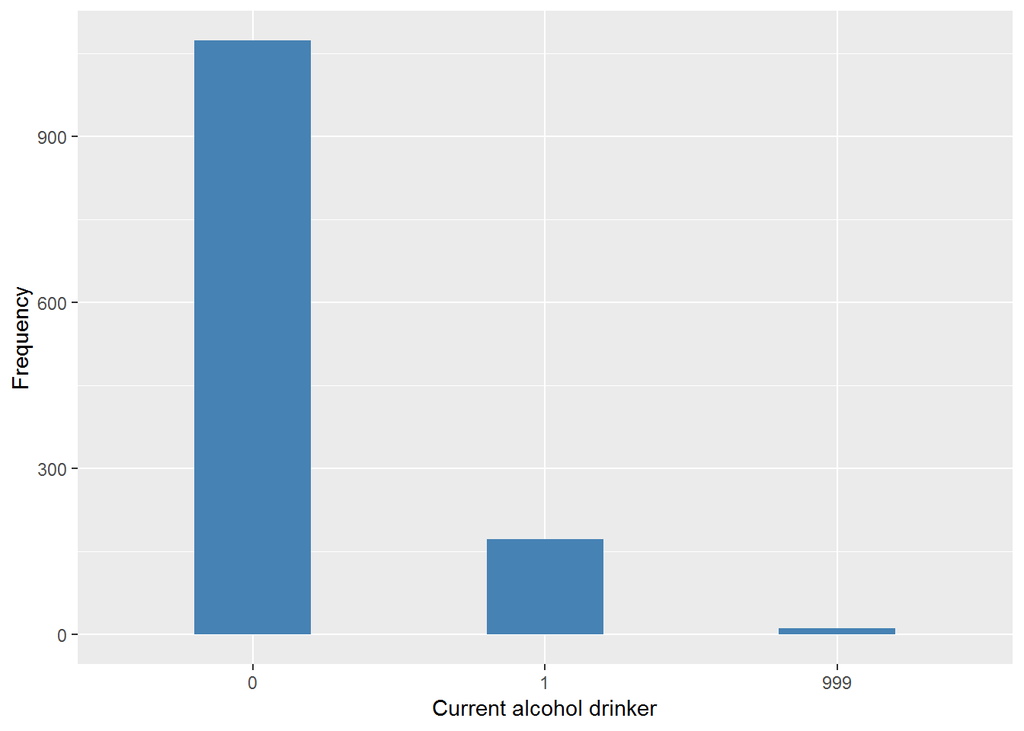

Frequency of alcohol drinking

| Sample size | Missing values |
| --- | --- |
| 1257 | 11 |

Category

|  | 0 | 1 | 2 |
| --- | --- | --- | --- |
| Frequency | 1073.00 | 63.00 | 110.00 |
| Percentage | 85.36 | 5.01 | 8.75 |

Type of missing

|  | 991 | 992 | 993 | 994 | 995 | 996 | 997 | 998 | 999 | NA |
| --- | --- | --- | --- | --- | --- | --- | --- | --- | --- | --- |
| Frequency | 0 | 0 | 0 | 0 | 0 | 0 | 0 | 0 | 11.00 | 0 |
| Percentage | 0 | 0 | 0 | 0 | 0 | 0 | 0 | 0 | 0.88 | 0 |

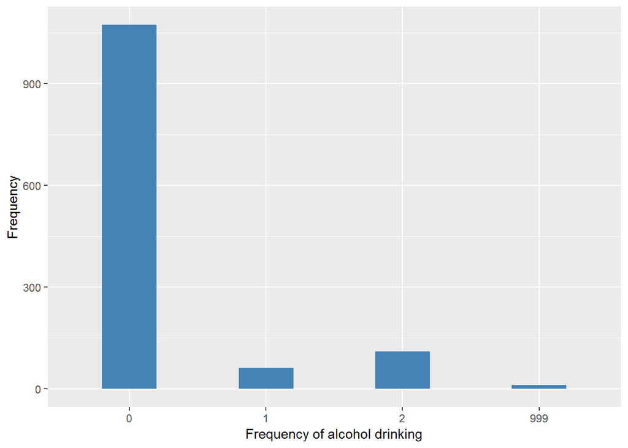

Past drinking

| Sample size | Missing values |
| --- | --- |
| 1257 | 522 |

Category

|  | 0 | 1 |
| --- | --- | --- |
| Frequency | 416.00 | 319.00 |
| Percentage | 33.09 | 25.38 |

Type of missing

|  | 991 | 992 | 993 | 994 | 995 | 996 | 997 | 998 | 999 | NA |
| --- | --- | --- | --- | --- | --- | --- | --- | --- | --- | --- |
| Frequency | 0 | 0 | 0 | 0 | 0 | 0 | 0 | 0 | 522.00 | 0 |
| Percentage | 0 | 0 | 0 | 0 | 0 | 0 | 0 | 0 | 41.53 | 0 |

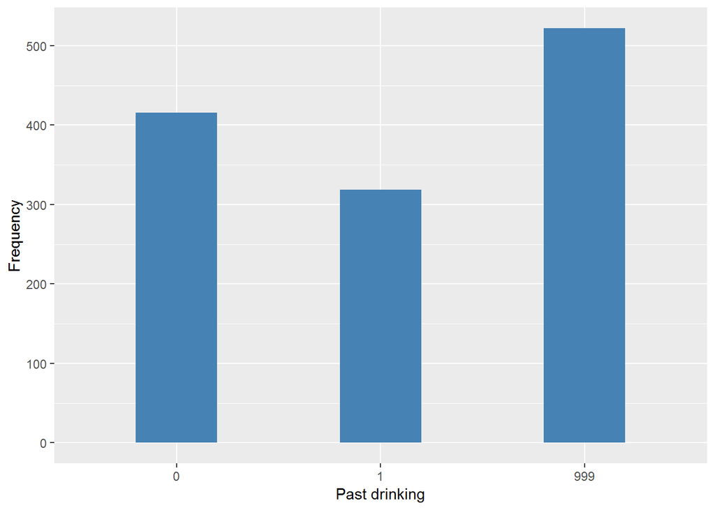

#### 2.6.2.4 Validation

## 2.7 Urban Peru

### 2.7.1 Wave 1

#### 2.7.1.1 Study-specific variable description

| **Name** | `PALCNOW` | `PALCPAST` |
| --- | --- | --- |
| **Label** | `alcohol - units drunk per week now` `1 unit = a small glass of beer = a single measure of spirits = 1 glass of wine or sherry` `32 units = 1 bottle of spirits` | `alcohol - units drunk per week before age of 65 years` `1 unit = a small glass of beer = a single measure of spirits = 1 glass of wine or sherry` `32 units = 1 bottle of spirits` |
| **Table name** | `1066-UrbanPeru-Baseline` | `1066-UrbanPeru-Baseline` |
| **Categories** | `continuous` | `continuous` |
| **Missings** | `NA` | `NA` |
| **Description** |  |  |

PALCNOW

| Sample size | Missing values |
| --- | --- |
| 1381 | 47 |

Summary

| Min. | 1st Qu. | Median | Mean | 3rd Qu. | Max. | NA’s |
| --- | --- | --- | --- | --- | --- | --- |
| 0 | 0 | 0 | 0.2819 | 0 | 192 | 47 |

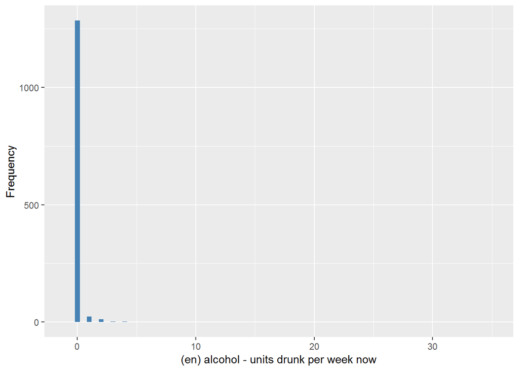

PALCPAST

| Sample size | Missing values |
| --- | --- |
| 1381 | 36 |

Summary

| Min. | 1st Qu. | Median | Mean | 3rd Qu. | Max. | NA’s |
| --- | --- | --- | --- | --- | --- | --- |
| 0 | 0 | 0 | 1.104 | 0 | 320 | 36 |

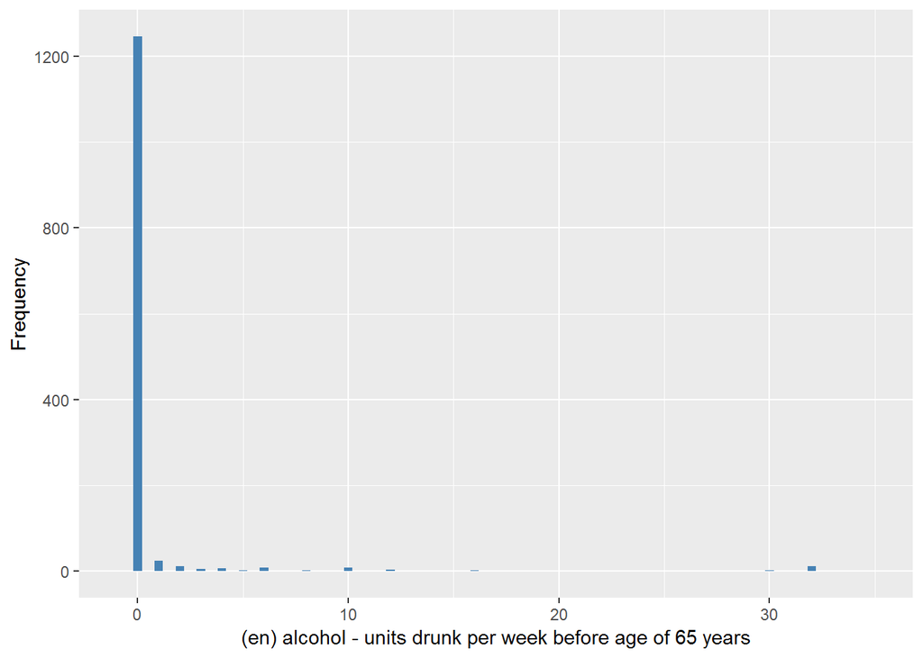

#### 2.7.1.2 Harmonisation algorithm

To compute `current_oh` from the study-specific variable it has to be recoded as follows:

- `PALCNOW == 0 into 0`
- `PALCNOW > 0 into 1`
- `NA into 999`

To compute `freq_oh` from the study-specific variable it has to be recoded as follows:

- `If PALCNOW=0 then 'drinking_frequency'=0`
- `if PALCNOW=1 or 2 then 'drinking_frequency'=1`
- `if PALCNOW>2 then 'drinking_frequency'=2`

To compute `past_oh` from the study-specific variable it has to be recoded as follows:

- `PALCPAST == 0 into 0`
- `PALCPAST > 0 into 1`
- `NA into 999`

**R script:**

```r
t1066_ds_UP_w1 <- tibble(id = t1066_UP_w1$id)
t1066_ds_UP_w1$freq_oh <- car::recode(t1066_UP_w1$PALCNOW, "0 = 0; c(1,2) = 1; 3:hi = 2; NA = 999")
t1066_ds_UP_w1$current_oh <- car::recode(t1066_ds_UP_w1$freq_oh, "2 = 1")
t1066_ds_UP_w1$past_oh <- car::recode(t1066_UP_w1$PALCPAST, "0 = 0; 1:hi = 1; NA = 999")
```

#### 2.7.1.3 Statistics of the new harmonized variable

Current alcohol drinker

| Sample size | Missing values |
| --- | --- |
| 1381 | 47 |

Category

|  | 0 | 1 |
| --- | --- | --- |
| Frequency | 1284.00 | 50.00 |
| Percentage | 92.98 | 3.62 |

Type of missing

|  | 991 | 992 | 993 | 994 | 995 | 996 | 997 | 998 | 999 | NA |
| --- | --- | --- | --- | --- | --- | --- | --- | --- | --- | --- |
| Frequency | 0 | 0 | 0 | 0 | 0 | 0 | 0 | 0 | 47.0 | 0 |
| Percentage | 0 | 0 | 0 | 0 | 0 | 0 | 0 | 0 | 3.4 | 0 |

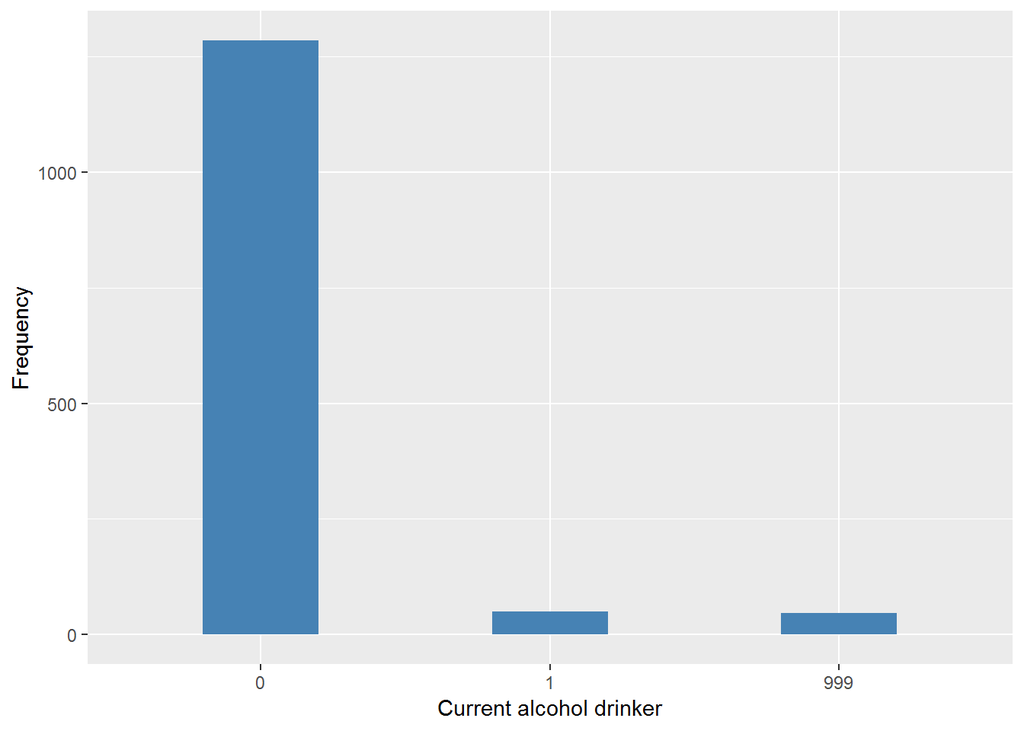

Frequency of alcohol drinking

| Sample size | Missing values |
| --- | --- |
| 1381 | 47 |

Category

|  | 0 | 1 | 2 |
| --- | --- | --- | --- |
| Frequency | 1284.00 | 37.00 | 13.00 |
| Percentage | 92.98 | 2.68 | 0.94 |

Type of missing

|  | 991 | 992 | 993 | 994 | 995 | 996 | 997 | 998 | 999 | NA |
| --- | --- | --- | --- | --- | --- | --- | --- | --- | --- | --- |
| Frequency | 0 | 0 | 0 | 0 | 0 | 0 | 0 | 0 | 47.0 | 0 |
| Percentage | 0 | 0 | 0 | 0 | 0 | 0 | 0 | 0 | 3.4 | 0 |

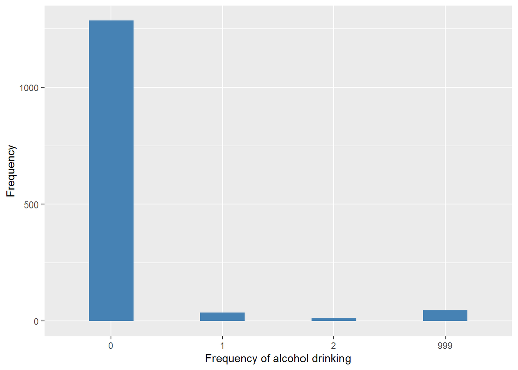

Past drinking

| Sample size | Missing values |
| --- | --- |
| 1381 | 36 |

Category

|  | 0 | 1 |
| --- | --- | --- |
| Frequency | 1246.00 | 99.00 |
| Percentage | 90.22 | 7.17 |

Type of missing

|  | 991 | 992 | 993 | 994 | 995 | 996 | 997 | 998 | 999 | NA |
| --- | --- | --- | --- | --- | --- | --- | --- | --- | --- | --- |
| Frequency | 0 | 0 | 0 | 0 | 0 | 0 | 0 | 0 | 36.00 | 0 |
| Percentage | 0 | 0 | 0 | 0 | 0 | 0 | 0 | 0 | 2.61 | 0 |

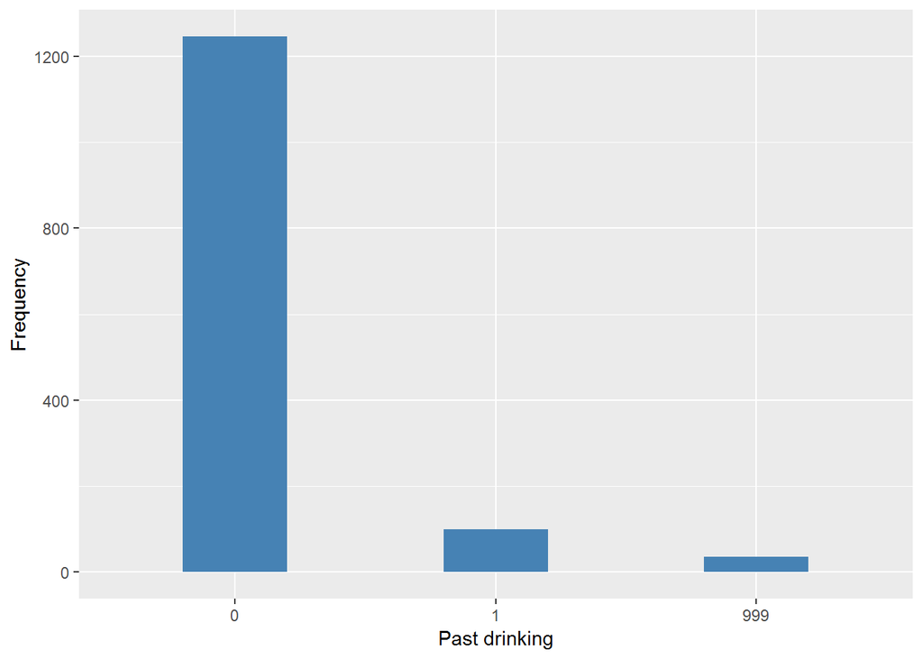

#### 2.7.1.4 Validation

### 2.7.2 Wave 2

#### 2.7.2.1 Study-specific variable description

| **Name** | `f_PALCPAST` |
| --- | --- |
| **Label** | `In the last week how much did you drink` `1 unit = a small glass of beer = a single measure of spirits = 1 glass of wine or sherry` `32 units = 1 bottle of spirits` |
| **Table name** | `1066-UrbanPeru-Followup` |
| **Categories** | `continuous` |
| **Missings** | `NA` |
| **Description** |  |

f_PALCPAST

| Sample size | Missing values |
| --- | --- |
| 890 | 1 |

Summary

| Min. | 1st Qu. | Median | Mean | 3rd Qu. | Max. | NA’s |
| --- | --- | --- | --- | --- | --- | --- |
| 0 | 0 | 0 | 0.7987 | 0 | 134 | 1 |

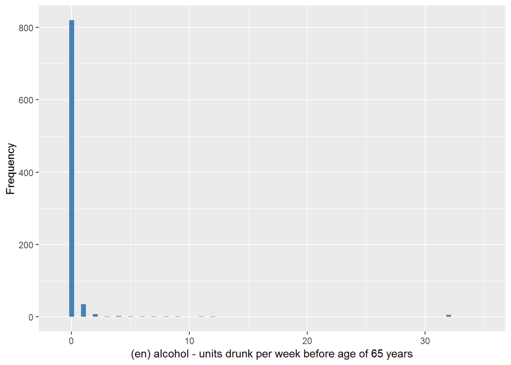

#### 2.7.2.2 Harmonisation algorithm

To compute `current_oh` from the study-specific variable it has to be recoded as follows:

- `f_PALCPAST == 0 into 0`
- `f_PALCPAST > 0 into 1`
- `NA into 999`

To compute `freq_oh` from the study-specific variable it has to be recoded as follows:

- `If f_PALCPAST=0 then 'drinking_frequency'=0`
- `if f_PALCPAST=1 or 2 then 'drinking_frequency'=1`
- `if f_PALCPAST>2 then 'drinking_frequency'=2`

To compute `past_oh` from the study-specific variable it has to be recoded as follows:

- `take from wave 1`

**R script:**

```r
t1066_ds_UP_w2 <- tibble(id = t1066_UP_w2$id)

t1066_ds_UP_w2$freq_oh <- car::recode(t1066_UP_w2$f_PALCPAST, "0 = 0; c(1,2) = 1; 3:hi = 2; NA = 999")
t1066_ds_UP_w2$current_oh <- car::recode(t1066_ds_UP_w2$freq_oh, "2 = 1")

t1066_UP_w2 <- left_join(t1066_UP_w2, t1066_ds_UP_w1, by = "id")
t1066_ds_UP_w2$past_oh <- t1066_UP_w2$past_oh
```

#### 2.7.2.3 Statistics of the new harmonized variable

Current alcohol drinker

| Sample size | Missing values |
| --- | --- |
| 890 | 1 |

Category

|  | 0 | 1 |
| --- | --- | --- |
| Frequency | 820.00 | 69.00 |
| Percentage | 92.13 | 7.75 |

Type of missing

|  | 991 | 992 | 993 | 994 | 995 | 996 | 997 | 998 | 999 | NA |
| --- | --- | --- | --- | --- | --- | --- | --- | --- | --- | --- |
| Frequency | 0 | 0 | 0 | 0 | 0 | 0 | 0 | 0 | 1.00 | 0 |
| Percentage | 0 | 0 | 0 | 0 | 0 | 0 | 0 | 0 | 0.11 | 0 |

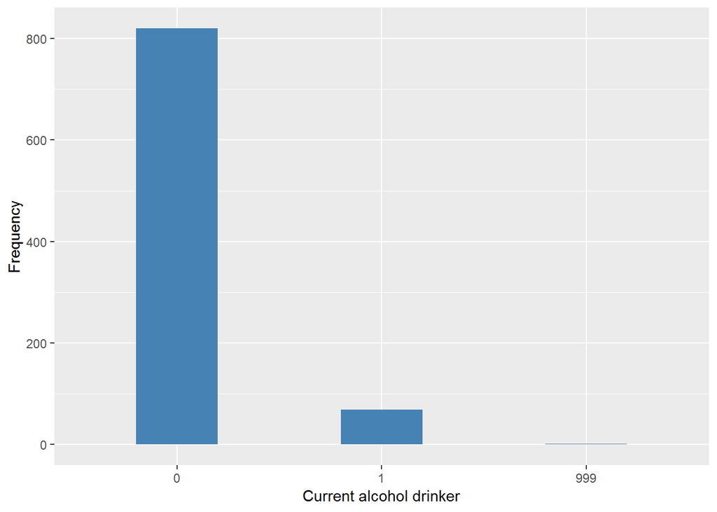

Frequency of alcohol drinking

| Sample size | Missing values |
| --- | --- |
| 890 | 1 |

Category

|  | 0 | 1 | 2 |
| --- | --- | --- | --- |
| Frequency | 820.00 | 43.00 | 26.00 |
| Percentage | 92.13 | 4.83 | 2.92 |

Type of missing

|  | 991 | 992 | 993 | 994 | 995 | 996 | 997 | 998 | 999 | NA |
| --- | --- | --- | --- | --- | --- | --- | --- | --- | --- | --- |
| Frequency | 0 | 0 | 0 | 0 | 0 | 0 | 0 | 0 | 1.00 | 0 |
| Percentage | 0 | 0 | 0 | 0 | 0 | 0 | 0 | 0 | 0.11 | 0 |

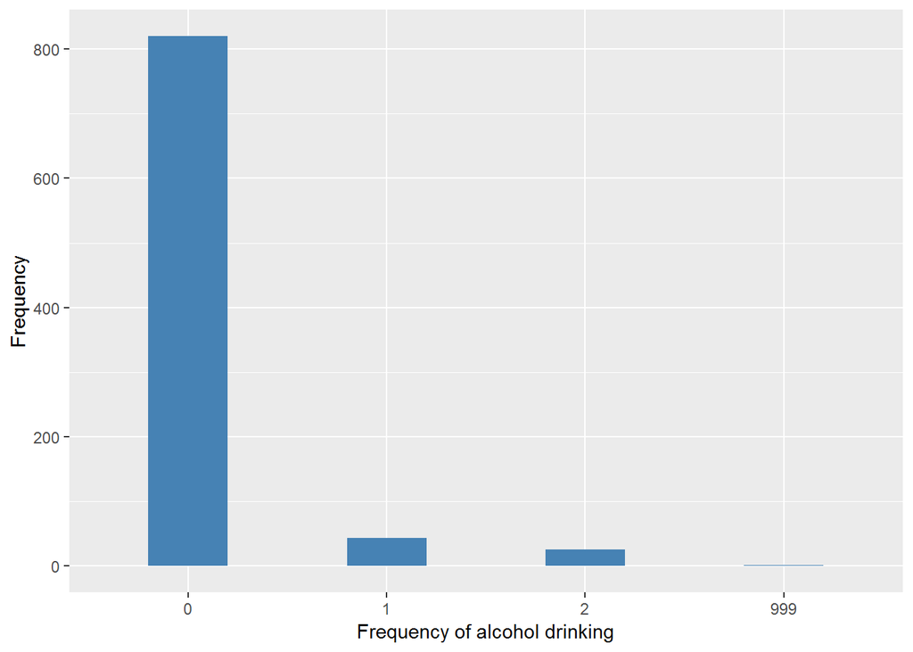

Past drinking

| Sample size | Missing values |
| --- | --- |
| 890 | 28 |

Category

|  | 0 | 1 |
| --- | --- | --- |
| Frequency | 808.00 | 54.00 |
| Percentage | 90.79 | 6.07 |

Type of missing

|  | 991 | 992 | 993 | 994 | 995 | 996 | 997 | 998 | 999 | NA |
| --- | --- | --- | --- | --- | --- | --- | --- | --- | --- | --- |
| Frequency | 0 | 0 | 0 | 0 | 0 | 0 | 0 | 0 | 28.00 | 0 |
| Percentage | 0 | 0 | 0 | 0 | 0 | 0 | 0 | 0 | 3.15 | 0 |

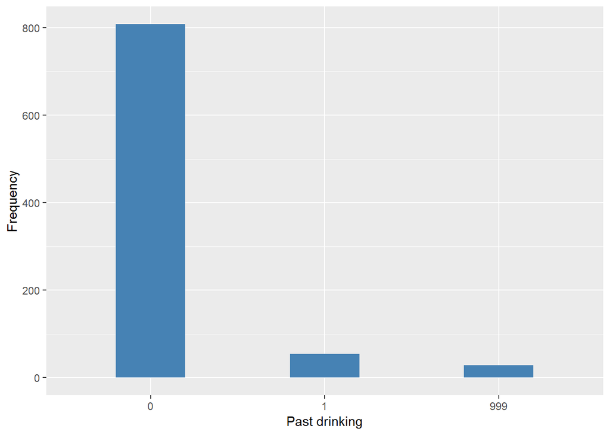

#### 2.7.2.4 Validation

## 2.8 Rural Peru

### 2.8.1 Wave 1

#### 2.8.1.1 Study-specific variable description

| **Name** | `PALCNOW` | `PALCPAST` |
| --- | --- | --- |
| **Label** | `alcohol - units drunk per week now` `1 unit = a small glass of beer = a single measure of spirits = 1 glass of wine or sherry` `32 units = 1 bottle of spirits` | `alcohol - units drunk per week before age of 65 years` `1 unit = a small glass of beer = a single measure of spirits = 1 glass of wine or sherry` `32 units = 1 bottle of spirits` |
| **Table name** | `1066-RuralPeru-Baseline` | `1066-RuralPeru-Baseline` |
| **Categories** | `continuous` | `continuous` |
| **Missings** | `NA` | `NA` |
| **Description** |  |  |

PALCNOW

| Sample size | Missing values |
| --- | --- |
| 552 | 4 |

Summary

| Min. | 1st Qu. | Median | Mean | 3rd Qu. | Max. | NA’s |
| --- | --- | --- | --- | --- | --- | --- |
| 0 | 0 | 0 | 0.3029 | 0 | 65 | 4 |

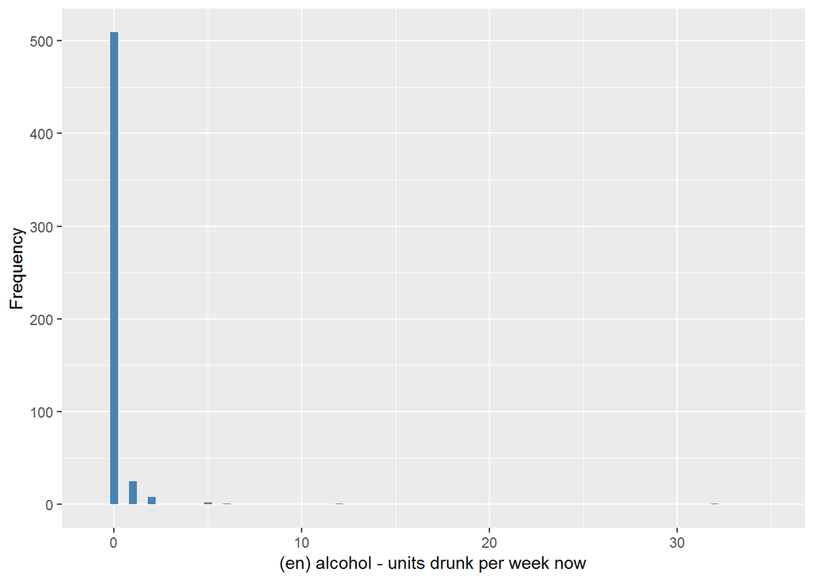

PALCPAST

| Sample size | Missing values |
| --- | --- |
| 552 | 5 |

Summary

| Min. | 1st Qu. | Median | Mean | 3rd Qu. | Max. | NA’s |
| --- | --- | --- | --- | --- | --- | --- |
| 0 | 0 | 0 | 1.26 | 0 | 64 | 5 |

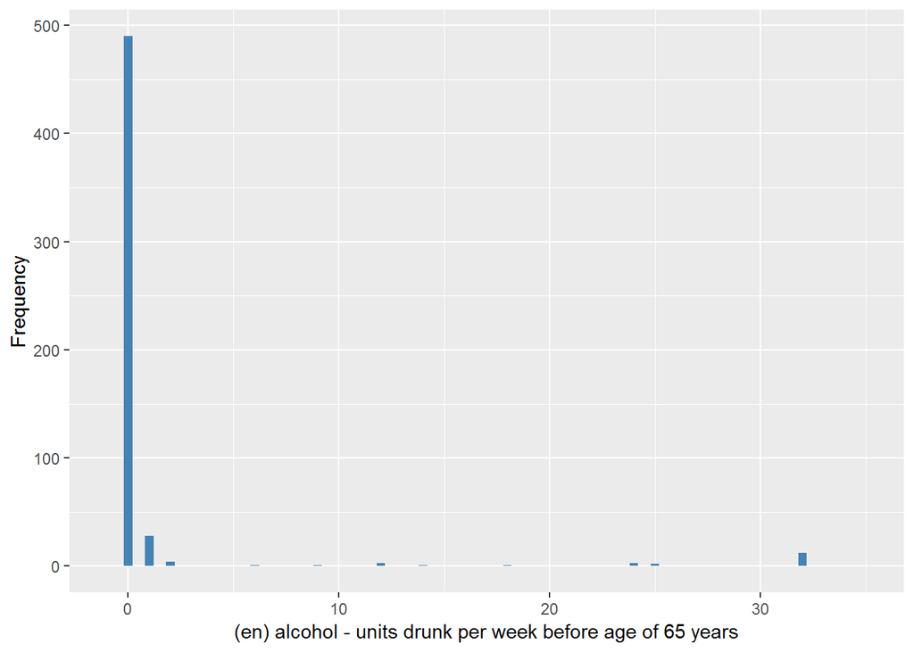

#### 2.8.1.2 Harmonisation algorithm

To compute `current_oh` from the study-specific variable it has to be recoded as follows:

- `PALCNOW == 0 into 0`
- `PALCNOW > 0 into 1`
- `NA into 999`

To compute `freq_oh` from the study-specific variable it has to be recoded as follows:

- `If PALCNOW=0 then 'drinking_frequency'=0`
- `if PALCNOW=1 or 2 then 'drinking_frequency'=1`
- `if PALCNOW>2 then 'drinking_frequency'=2`

To compute `past_oh` from the study-specific variable it has to be recoded as follows:

- `PALCPAST == 0 into 0`
- `PALCPAST > 0 into 1`
- `NA into 999`

**R script:**

```r
t1066_ds_RP_w1 <- tibble(id = t1066_RP_w1$id)
t1066_ds_RP_w1$freq_oh <- car::recode(t1066_RP_w1$PALCNOW, "0 = 0; c(1,2) = 1; 3:hi = 2; NA = 999")
t1066_ds_RP_w1$current_oh <- car::recode(t1066_ds_RP_w1$freq_oh, "2 = 1")
t1066_ds_RP_w1$past_oh <- car::recode(t1066_RP_w1$PALCPAST, "0 = 0; 1:hi = 1; NA = 999")
```

#### 2.8.1.3 Statistics of the new harmonized variable

Current alcohol drinker

| Sample size | Missing values |
| --- | --- |
| 552 | 4 |

Category

|  | 0 | 1 |
| --- | --- | --- |
| Frequency | 509.00 | 39.00 |
| Percentage | 92.21 | 7.07 |

Type of missing

|  | 991 | 992 | 993 | 994 | 995 | 996 | 997 | 998 | 999 | NA |
| --- | --- | --- | --- | --- | --- | --- | --- | --- | --- | --- |
| Frequency | 0 | 0 | 0 | 0 | 0 | 0 | 0 | 0 | 4.00 | 0 |
| Percentage | 0 | 0 | 0 | 0 | 0 | 0 | 0 | 0 | 0.72 | 0 |

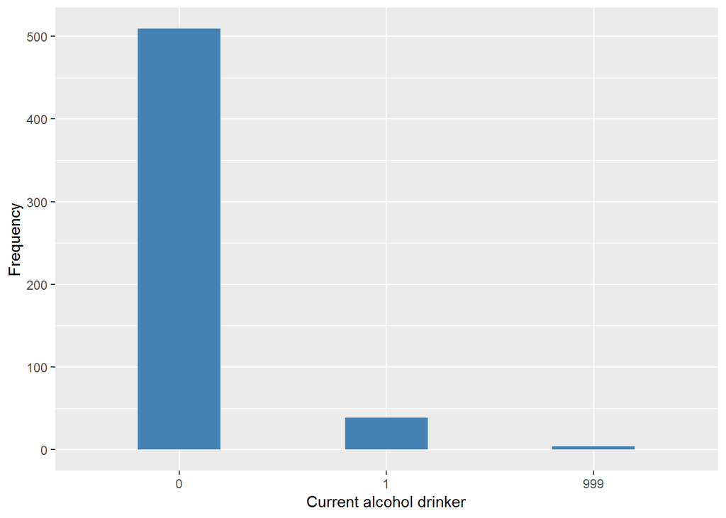

Frequency of alcohol drinking

| Sample size | Missing values |
| --- | --- |
| 552 | 4 |

Category

|  | 0 | 1 | 2 |
| --- | --- | --- | --- |
| Frequency | 509.00 | 33.00 | 6.00 |
| Percentage | 92.21 | 5.98 | 1.09 |

Type of missing

|  | 991 | 992 | 993 | 994 | 995 | 996 | 997 | 998 | 999 | NA |
| --- | --- | --- | --- | --- | --- | --- | --- | --- | --- | --- |
| Frequency | 0 | 0 | 0 | 0 | 0 | 0 | 0 | 0 | 4.00 | 0 |
| Percentage | 0 | 0 | 0 | 0 | 0 | 0 | 0 | 0 | 0.72 | 0 |

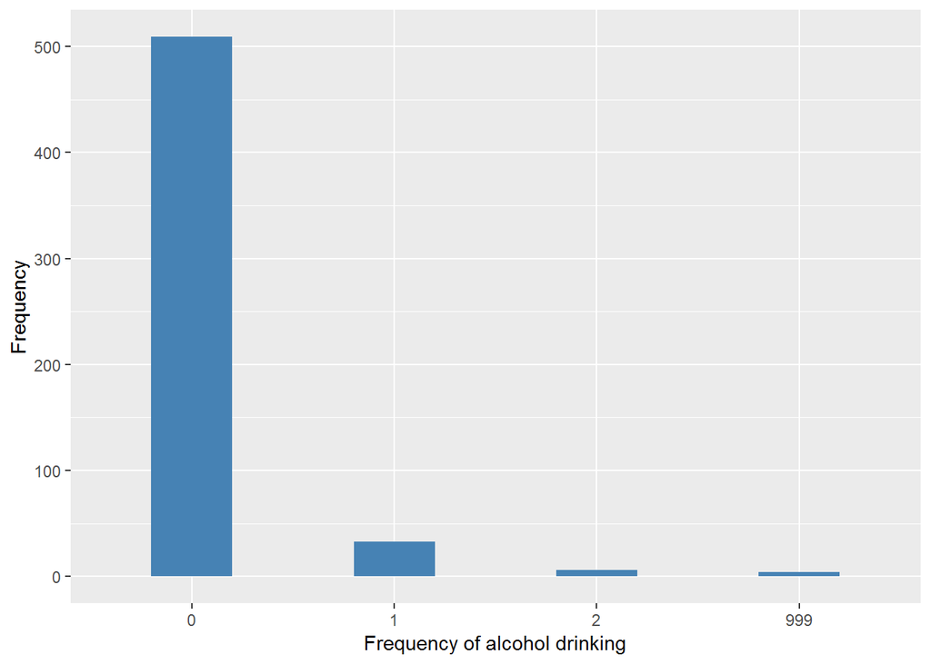

Past drinking

| Sample size | Missing values |
| --- | --- |
| 552 | 5 |

Category

|  | 0 | 1 |
| --- | --- | --- |
| Frequency | 490.00 | 57.00 |
| Percentage | 88.77 | 10.33 |

Type of missing

|  | 991 | 992 | 993 | 994 | 995 | 996 | 997 | 998 | 999 | NA |
| --- | --- | --- | --- | --- | --- | --- | --- | --- | --- | --- |
| Frequency | 0 | 0 | 0 | 0 | 0 | 0 | 0 | 0 | 5.00 | 0 |
| Percentage | 0 | 0 | 0 | 0 | 0 | 0 | 0 | 0 | 0.91 | 0 |

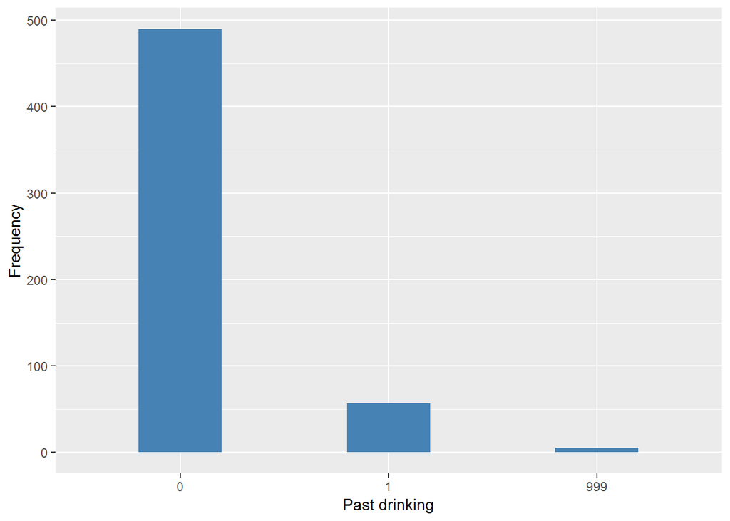

#### 2.8.1.4 Validation

### 2.8.2 Wave 2

#### 2.8.2.1 Study-specific variable description

| **Name** | `f_PALCPAST` |
| --- | --- |
| **Label** | `In the last week how much did you drink` `1 unit = a small glass of beer = a single measure of spirits = 1 glass of wine or sherry` `32 units = 1 bottle of spirits` |
| **Table name** | `1066-RuralPeru-Followup` |
| **Categories** | `continuous` |
| **Missings** | `NA` |
| **Description** |  |

f_PALCPAST

| Sample size | Missing values |
| --- | --- |
| 421 | 0 |

Summary

| Min. | 1st Qu. | Median | Mean | 3rd Qu. | Max. |
| --- | --- | --- | --- | --- | --- |
| 0 | 0 | 0 | 0.7981 | 0 | 96 |

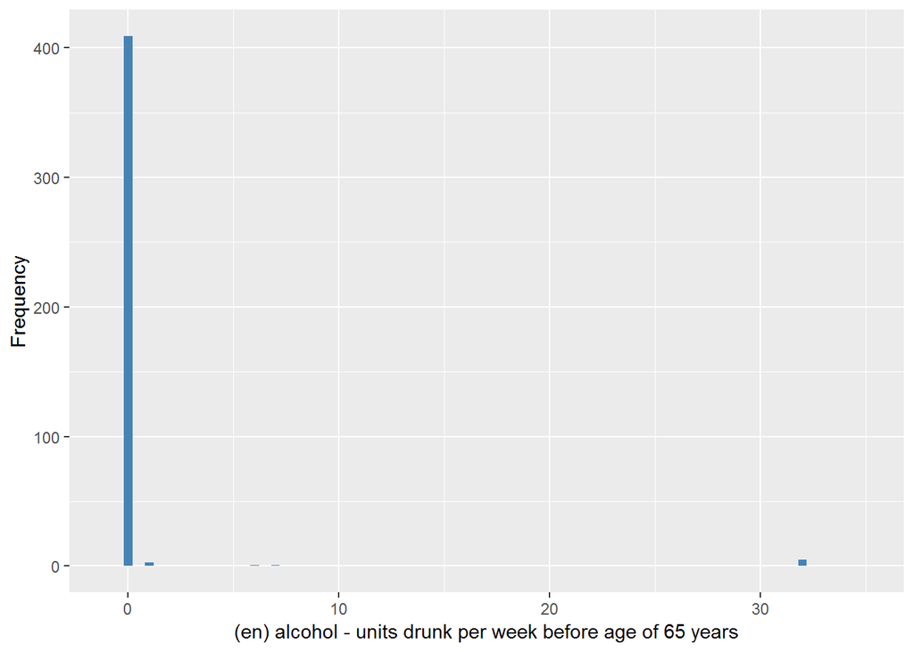

#### 2.8.2.2 Harmonisation algorithm

To compute `current_oh` from the study-specific variable it has to be recoded as follows:

- `f_PALCPAST == 0 into 0`
- `f_PALCPAST > 0 into 1`
- `NA into 999`

To compute `freq_oh` from the study-specific variable it has to be recoded as follows:

- `If f_PALCPAST=0 then 'drinking_frequency'=0`
- `if f_PALCPAST=1 or 2 then 'drinking_frequency'=1`
- `if f_PALCPAST>2 then 'drinking_frequency'=2`

To compute `past_oh` from the study-specific variable it has to be recoded as follows:

- `take from wave 1`

**R script:**

```r
t1066_ds_RP_w2 <- tibble(id = t1066_RP_w2$id)

t1066_ds_RP_w2$freq_oh <- car::recode(t1066_RP_w2$f_PALCPAST, "0 = 0; c(1,2) = 1; 3:hi = 2; NA = 999")
t1066_ds_RP_w2$current_oh <- car::recode(t1066_ds_RP_w2$freq_oh, "2 = 1")

t1066_RP_w2 <- left_join(t1066_RP_w2, t1066_ds_RP_w1, by = "id")
t1066_ds_RP_w2$past_oh <- t1066_RP_w2$past_oh
```

#### 2.8.2.3 Statistics of the new harmonized variable

Current alcohol drinker

| Sample size | Missing values |
| --- | --- |
| 421 | 0 |

Category

|  | 0 | 1 |
| --- | --- | --- |
| Frequency | 409.00 | 12.00 |
| Percentage | 97.15 | 2.85 |

Type of missing

|  | 991 | 992 | 993 | 994 | 995 | 996 | 997 | 998 | 999 | NA |
| --- | --- | --- | --- | --- | --- | --- | --- | --- | --- | --- |
| Frequency | 0 | 0 | 0 | 0 | 0 | 0 | 0 | 0 | 0 | 0 |
| Percentage | 0 | 0 | 0 | 0 | 0 | 0 | 0 | 0 | 0 | 0 |

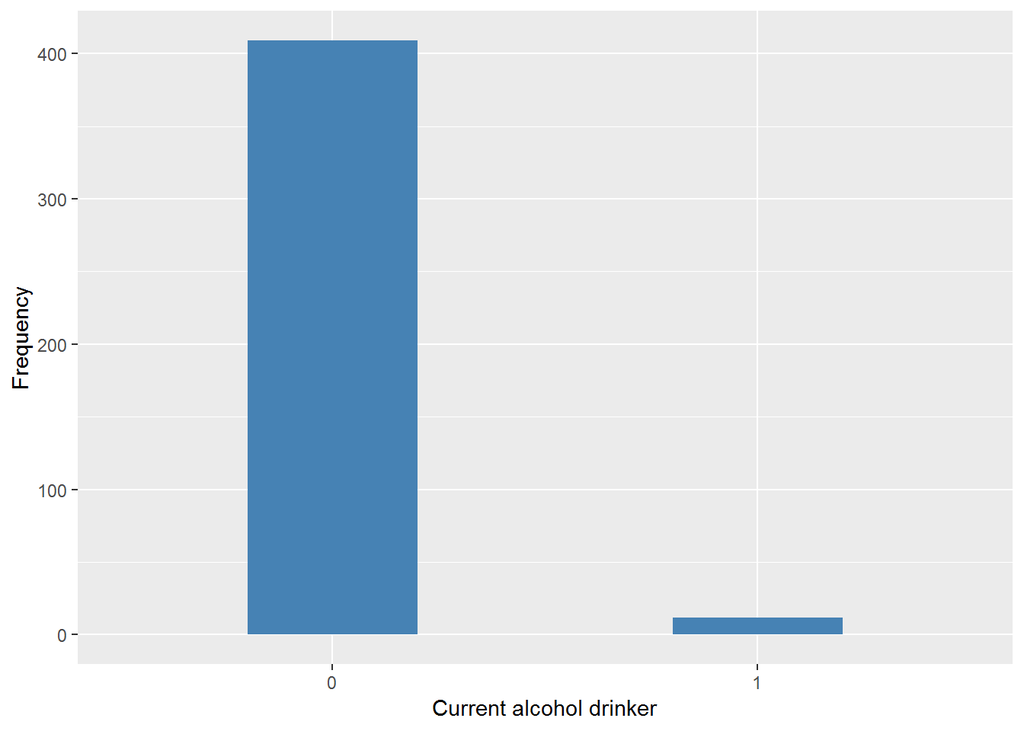

Frequency of alcohol drinking

| Sample size | Missing values |
| --- | --- |
| 421 | 0 |

Category

|  | 0 | 1 | 2 |
| --- | --- | --- | --- |
| Frequency | 409.00 | 3.00 | 9.00 |
| Percentage | 97.15 | 0.71 | 2.14 |

Type of missing

|  | 991 | 992 | 993 | 994 | 995 | 996 | 997 | 998 | 999 | NA |
| --- | --- | --- | --- | --- | --- | --- | --- | --- | --- | --- |
| Frequency | 0 | 0 | 0 | 0 | 0 | 0 | 0 | 0 | 0 | 0 |
| Percentage | 0 | 0 | 0 | 0 | 0 | 0 | 0 | 0 | 0 | 0 |

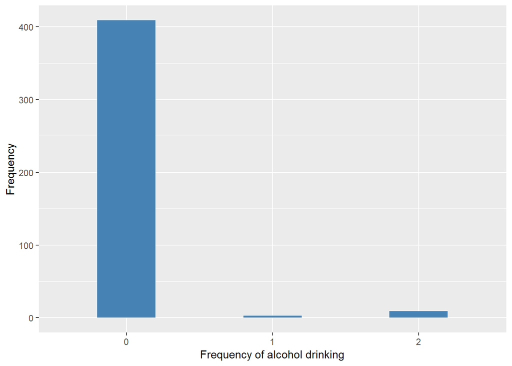

Past drinking

| Sample size | Missing values |
| --- | --- |
| 421 | 3 |

Category

|  | 0 | 1 |
| --- | --- | --- |
| Frequency | 376.00 | 42.00 |
| Percentage | 89.31 | 9.98 |

Type of missing

|  | 991 | 992 | 993 | 994 | 995 | 996 | 997 | 998 | 999 | NA |
| --- | --- | --- | --- | --- | --- | --- | --- | --- | --- | --- |
| Frequency | 0 | 0 | 0 | 0 | 0 | 0 | 0 | 0 | 3.00 | 0 |
| Percentage | 0 | 0 | 0 | 0 | 0 | 0 | 0 | 0 | 0.71 | 0 |

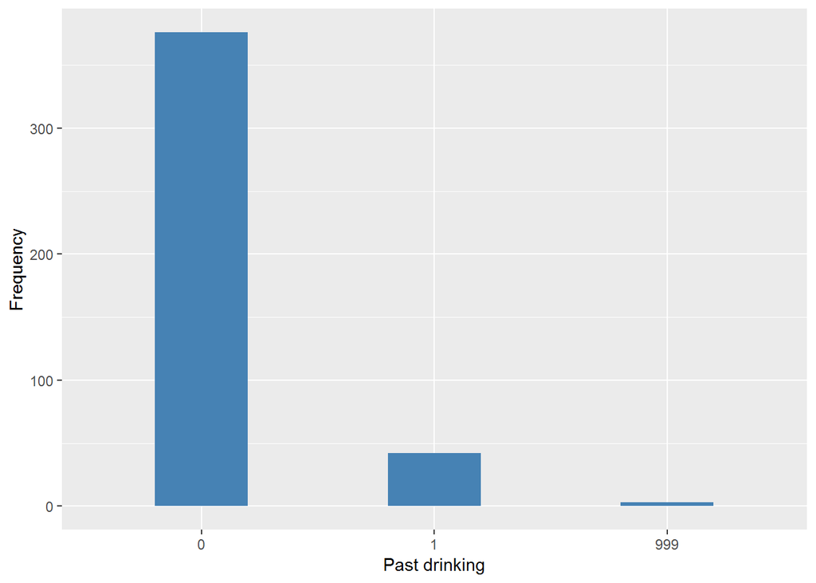

#### 2.8.2.4 Validation

## 2.9 Urban Mexico

### 2.9.1 Wave 1

#### 2.9.1.1 Study-specific variable description

| **Name** | `PALCNOW` | `PALCPAST` |
| --- | --- | --- |
| **Label** | `alcohol - units drunk per week now` `1 unit = a small glass of beer = a single measure of spirits = 1 glass of wine or sherry` `32 units = 1 bottle of spirits` | `alcohol - units drunk per week before age of 65 years` `1 unit = a small glass of beer = a single measure of spirits = 1 glass of wine or sherry` `32 units = 1 bottle of spirits` |
| **Table name** | `1066-UrbanMexico-Baseline` | `1066-UrbanMexico-Baseline` |
| **Categories** | `continuous` | `continuous` |
| **Missings** | `NA` | `NA` |
| **Description** |  |  |

PALCNOW

| Sample size | Missing values |
| --- | --- |
| 1003 | 13 |

Summary

| Min. | 1st Qu. | Median | Mean | 3rd Qu. | Max. | NA’s |
| --- | --- | --- | --- | --- | --- | --- |
| 0 | 0 | 0 | 0.8212 | 0 | 64 | 13 |

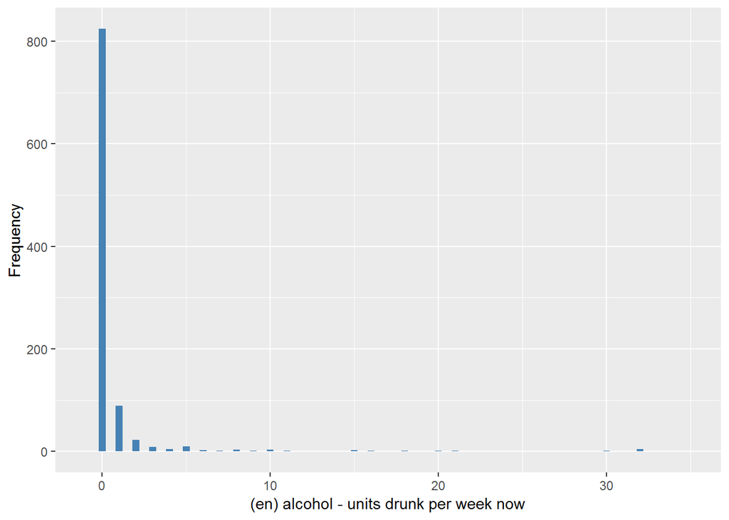

PALCPAST

| Sample size | Missing values |
| --- | --- |
| 1003 | 12 |

Summary

| Min. | 1st Qu. | Median | Mean | 3rd Qu. | Max. | NA’s |
| --- | --- | --- | --- | --- | --- | --- |
| 0 | 0 | 0 | 4.779 | 1 | 140 | 12 |

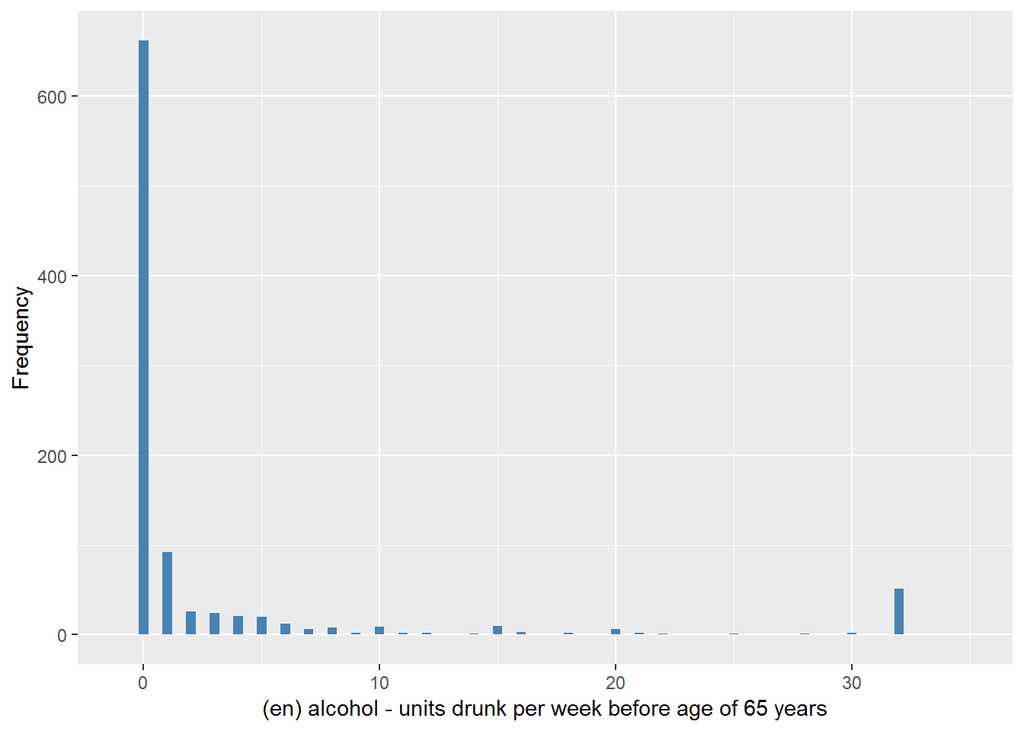

#### 2.9.1.2 Harmonisation algorithm

To compute `current_oh` from the study-specific variable it has to be recoded as follows:

- `PALCNOW == 0 into 0`
- `PALCNOW > 0 into 1`
- `NA into 999`

To compute `freq_oh` from the study-specific variable it has to be recoded as follows:

- `If PALCNOW=0 then 'drinking_frequency'=0`
- `if PALCNOW=1 or 2 then 'drinking_frequency'=1`
- `if PALCNOW>2 then 'drinking_frequency'=2`

To compute `past_oh` from the study-specific variable it has to be recoded as follows:

- `PALCPAST == 0 into 0`
- `PALCPAST > 0 into 1`
- `NA into 999`

**R script:**

```r
t1066_ds_UM_w1 <- tibble(id = t1066_UM_w1$id)
t1066_ds_UM_w1$freq_oh <- car::recode(t1066_UM_w1$PALCNOW, "0 = 0; c(1,2) = 1; 3:hi = 2; NA = 999")
t1066_ds_UM_w1$current_oh <- car::recode(t1066_ds_UM_w1$freq_oh, "2 = 1")
t1066_ds_UM_w1$past_oh <- car::recode(t1066_UM_w1$PALCPAST, "0 = 0; 1:hi = 1; NA = 999")
```

#### 2.9.1.3 Statistics of the new harmonized variable

Current alcohol drinker

| Sample size | Missing values |
| --- | --- |
| 1003 | 13 |

Category

|  | 0 | 1 |
| --- | --- | --- |
| Frequency | 824.00 | 166.00 |
| Percentage | 82.15 | 16.55 |

Type of missing

|  | 991 | 992 | 993 | 994 | 995 | 996 | 997 | 998 | 999 | NA |
| --- | --- | --- | --- | --- | --- | --- | --- | --- | --- | --- |
| Frequency | 0 | 0 | 0 | 0 | 0 | 0 | 0 | 0 | 13.0 | 0 |
| Percentage | 0 | 0 | 0 | 0 | 0 | 0 | 0 | 0 | 1.3 | 0 |

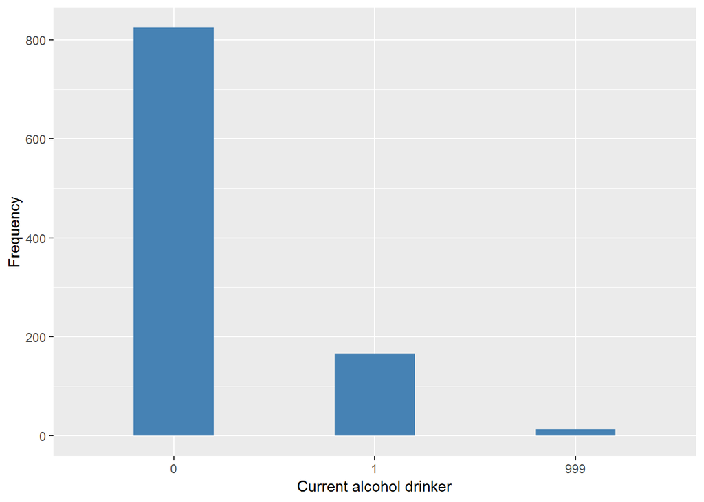

Frequency of alcohol drinking

| Sample size | Missing values |
| --- | --- |
| 1003 | 13 |

Category

|  | 0 | 1 | 2 |
| --- | --- | --- | --- |
| Frequency | 824.00 | 112.00 | 54.00 |
| Percentage | 82.15 | 11.17 | 5.38 |

Type of missing

|  | 991 | 992 | 993 | 994 | 995 | 996 | 997 | 998 | 999 | NA |
| --- | --- | --- | --- | --- | --- | --- | --- | --- | --- | --- |
| Frequency | 0 | 0 | 0 | 0 | 0 | 0 | 0 | 0 | 13.0 | 0 |
| Percentage | 0 | 0 | 0 | 0 | 0 | 0 | 0 | 0 | 1.3 | 0 |

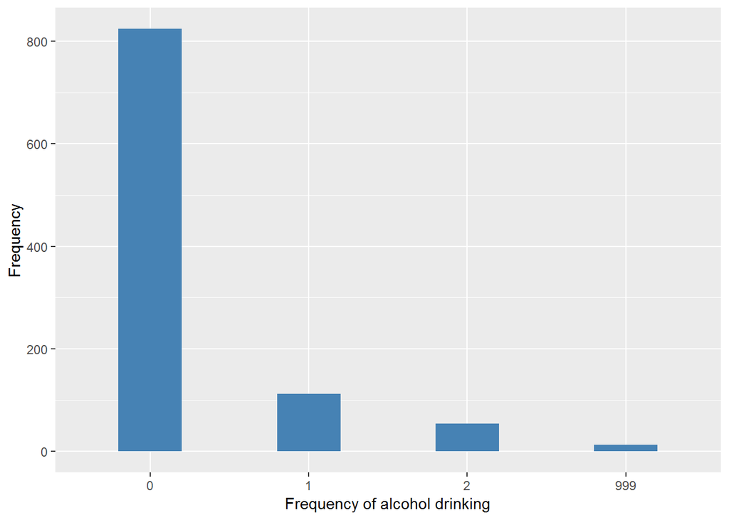

Past drinking

| Sample size | Missing values |
| --- | --- |
| 1003 | 12 |

Category

|  | 0 | 1 |
| --- | --- | --- |
| Frequency | 662 | 329.0 |
| Percentage | 66 | 32.8 |

Type of missing

|  | 991 | 992 | 993 | 994 | 995 | 996 | 997 | 998 | 999 | NA |
| --- | --- | --- | --- | --- | --- | --- | --- | --- | --- | --- |
| Frequency | 0 | 0 | 0 | 0 | 0 | 0 | 0 | 0 | 12.0 | 0 |
| Percentage | 0 | 0 | 0 | 0 | 0 | 0 | 0 | 0 | 1.2 | 0 |

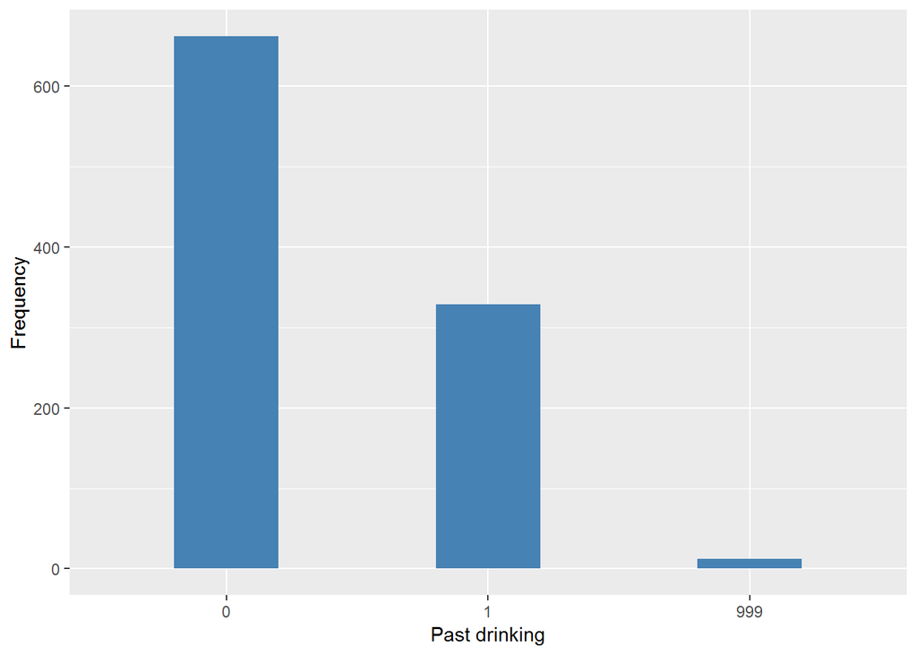

#### 2.9.1.4 Validation

### 2.9.2 Wave 2

#### 2.9.2.1 Study-specific variable description

| **Name** | `f_PALCPAST` |
| --- | --- |
| **Label** | `In the last week how much did you drink` `1 unit = a small glass of beer = a single measure of spirits = 1 glass of wine or sherry` `32 units = 1 bottle of spirits` |
| **Table name** | `1066-UrbanMexico-Followup` |
| **Categories** | `continuous` |
| **Missings** | `NA` |
| **Description** |  |

f_PALCPAST

| Sample size | Missing values |
| --- | --- |
| 749 | 2 |

Summary

| Min. | 1st Qu. | Median | Mean | 3rd Qu. | Max. | NA’s |
| --- | --- | --- | --- | --- | --- | --- |
| 0 | 0 | 0 | 0.3762 | 0 | 64 | 2 |

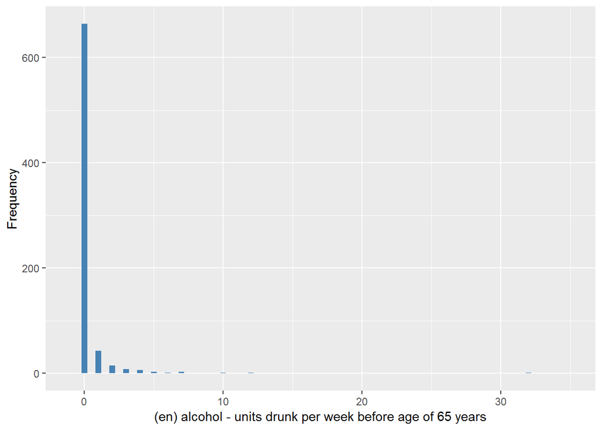

#### 2.9.2.2 Harmonisation algorithm

To compute `current_oh` from the study-specific variable it has to be recoded as follows:

- `f_PALCPAST == 0 into 0`
- `f_PALCPAST > 0 into 1`
- `NA into 999`

To compute `freq_oh` from the study-specific variable it has to be recoded as follows:

- `If f_PALCPAST=0 then 'drinking_frequency'=0`
- `if f_PALCPAST=1 or 2 then 'drinking_frequency'=1`
- `if f_PALCPAST>2 then 'drinking_frequency'=2`

To compute `past_oh` from the study-specific variable it has to be recoded as follows:

- `take from wave 1`

**R script:**

```r
t1066_ds_UM_w2 <- tibble(id = t1066_UM_w2$id)

t1066_ds_UM_w2$freq_oh <- car::recode(t1066_UM_w2$f_PALCPAST, "0 = 0; c(1,2) = 1; 3:hi = 2; NA = 999")
t1066_ds_UM_w2$current_oh <- car::recode(t1066_ds_UM_w2$freq_oh, "2 = 1")

t1066_UM_w2 <- left_join(t1066_UM_w2, t1066_ds_UM_w1, by = "id")
t1066_ds_UM_w2$past_oh <- t1066_UM_w2$past_oh
```

#### 2.9.2.3 Statistics of the new harmonized variable

Current alcohol drinker

| Sample size | Missing values |
| --- | --- |
| 749 | 2 |

Category

|  | 0 | 1 |
| --- | --- | --- |
| Frequency | 664.00 | 83.00 |
| Percentage | 88.65 | 11.08 |

Type of missing

|  | 991 | 992 | 993 | 994 | 995 | 996 | 997 | 998 | 999 | NA |
| --- | --- | --- | --- | --- | --- | --- | --- | --- | --- | --- |
| Frequency | 0 | 0 | 0 | 0 | 0 | 0 | 0 | 0 | 2.00 | 0 |
| Percentage | 0 | 0 | 0 | 0 | 0 | 0 | 0 | 0 | 0.27 | 0 |

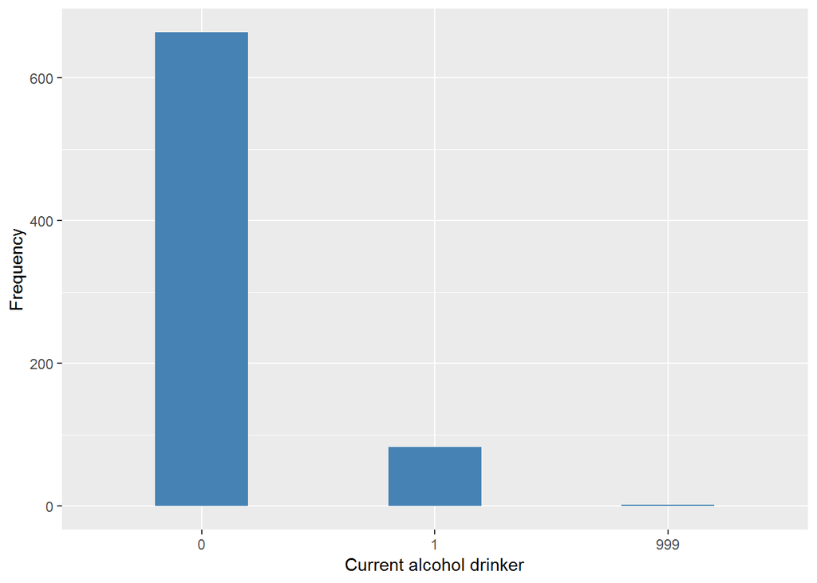

Frequency of alcohol drinking

| Sample size | Missing values |
| --- | --- |
| 749 | 2 |

Category

|  | 0 | 1 | 2 |
| --- | --- | --- | --- |
| Frequency | 664.00 | 58.00 | 25.00 |
| Percentage | 88.65 | 7.74 | 3.34 |

Type of missing

|  | 991 | 992 | 993 | 994 | 995 | 996 | 997 | 998 | 999 | NA |
| --- | --- | --- | --- | --- | --- | --- | --- | --- | --- | --- |
| Frequency | 0 | 0 | 0 | 0 | 0 | 0 | 0 | 0 | 2.00 | 0 |
| Percentage | 0 | 0 | 0 | 0 | 0 | 0 | 0 | 0 | 0.27 | 0 |

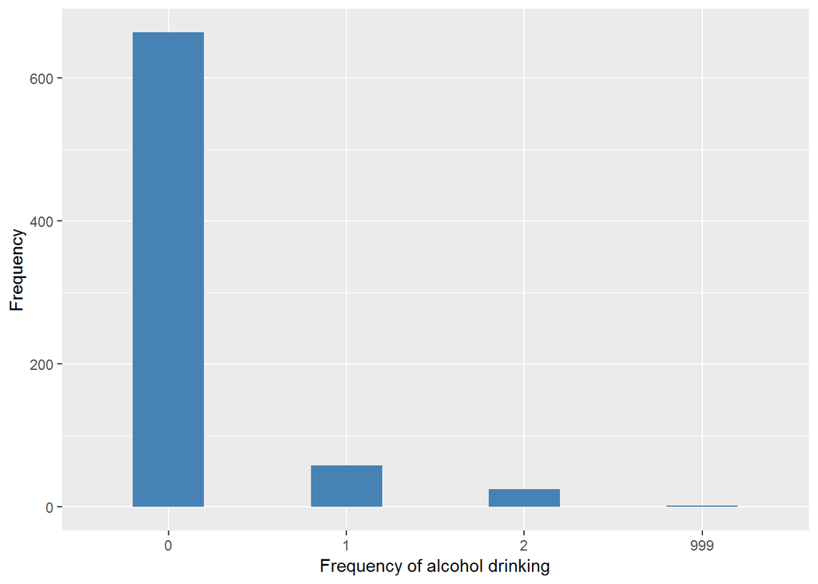

Past drinking

| Sample size | Missing values |
| --- | --- |
| 749 | 8 |

Category

|  | 0 | 1 |
| --- | --- | --- |
| Frequency | 482.00 | 259.00 |
| Percentage | 64.35 | 34.58 |

Type of missing

|  | 991 | 992 | 993 | 994 | 995 | 996 | 997 | 998 | 999 | NA |
| --- | --- | --- | --- | --- | --- | --- | --- | --- | --- | --- |
| Frequency | 0 | 0 | 0 | 0 | 0 | 0 | 0 | 0 | 8.00 | 0 |
| Percentage | 0 | 0 | 0 | 0 | 0 | 0 | 0 | 0 | 1.07 | 0 |

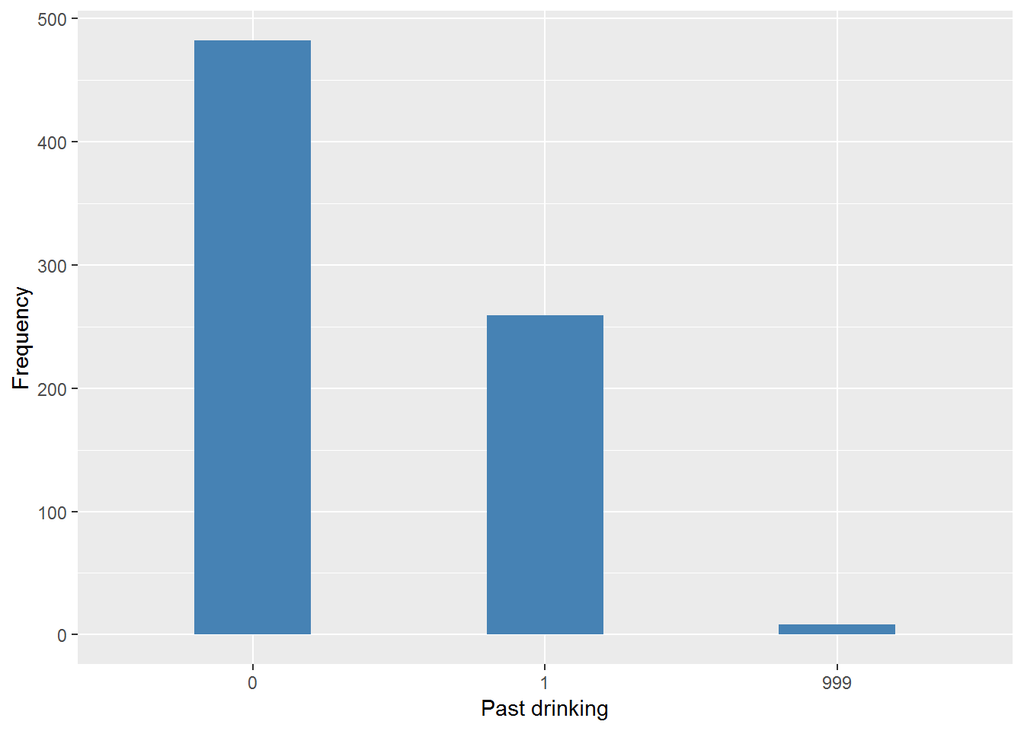

#### 2.9.2.4 Validation

## 2.10 Rural Mexico

### 2.10.1 Wave 1

#### 2.10.1.1 Study-specific variable description

| **Name** | `PALCNOW` | `PALCPAST` |
| --- | --- | --- |
| **Label** | `alcohol - units drunk per week now` `1 unit = a small glass of beer = a single measure of spirits = 1 glass of wine or sherry` `32 units = 1 bottle of spirits` | `alcohol - units drunk per week before age of 65 years` `1 unit = a small glass of beer = a single measure of spirits = 1 glass of wine or sherry` `32 units = 1 bottle of spirits` |
| **Table name** | `1066-RuralMexico-Baseline` | `1066-RuralMexico-Baseline` |
| **Categories** | `continuous` | `continuous` |
| **Missings** | `NA` | `NA` |
| **Description** |  |  |

PALCNOW

| Sample size | Missing values |
| --- | --- |
| 1000 | 4 |

Summary

| Min. | 1st Qu. | Median | Mean | 3rd Qu. | Max. | NA’s |
| --- | --- | --- | --- | --- | --- | --- |
| 0 | 0 | 0 | 1.277 | 0 | 160 | 4 |

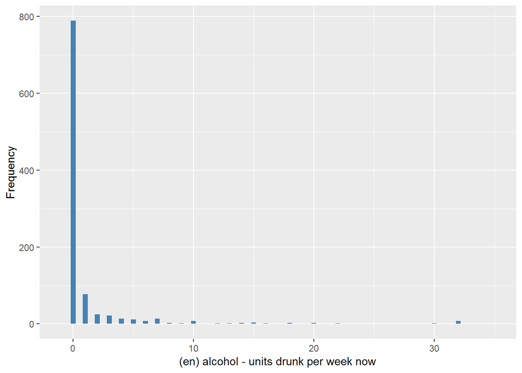

PALCPAST

| Sample size | Missing values |
| --- | --- |
| 1000 | 7 |

Summary

| Min. | 1st Qu. | Median | Mean | 3rd Qu. | Max. | NA’s |
| --- | --- | --- | --- | --- | --- | --- |
| 0 | 0 | 0 | 7.343 | 5 | 160 | 7 |

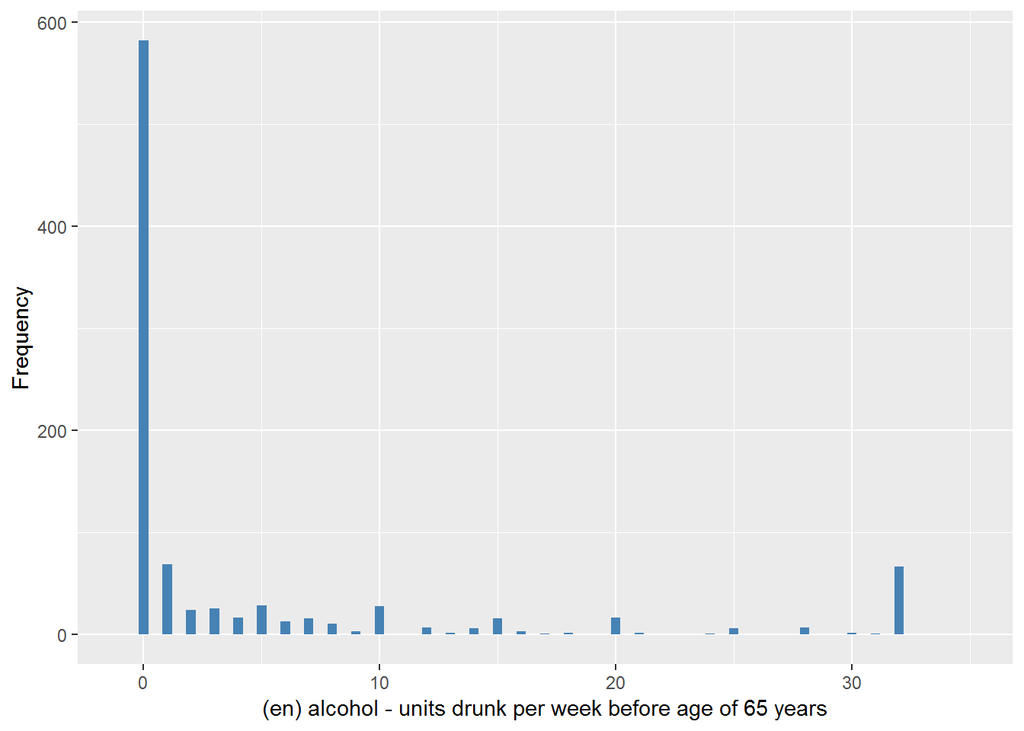

#### 2.10.1.2 Harmonisation algorithm

To compute `current_oh` from the study-specific variable it has to be recoded as follows:

- `PALCNOW == 0 into 0`
- `PALCNOW > 0 into 1`
- `NA into 999`

To compute `freq_oh` from the study-specific variable it has to be recoded as follows:

- `If PALCNOW=0 then 'drinking_frequency'=0`
- `if PALCNOW=1 or 2 then 'drinking_frequency'=1`
- `if PALCNOW>2 then 'drinking_frequency'=2`

To compute `past_oh` from the study-specific variable it has to be recoded as follows:

- `PALCPAST == 0 into 0`
- `PALCPAST > 0 into 1`
- `NA into 999`

**R script:**

```r
t1066_ds_RM_w1 <- tibble(id = t1066_RM_w1$id)
t1066_ds_RM_w1$freq_oh <- car::recode(t1066_RM_w1$PALCNOW, "0 = 0; c(1,2) = 1; 3:hi = 2; NA = 999")
t1066_ds_RM_w1$current_oh <- car::recode(t1066_ds_RM_w1$freq_oh, "2 = 1")
t1066_ds_RM_w1$past_oh <- car::recode(t1066_RM_w1$PALCPAST, "0 = 0; 1:hi = 1; NA = 999")
```

#### 2.10.1.3 Statistics of the new harmonized variable

Current alcohol drinker

| Sample size | Missing values |
| --- | --- |
| 1000 | 4 |

Category

|  | 0 | 1 |
| --- | --- | --- |
| Frequency | 789.0 | 207.0 |
| Percentage | 78.9 | 20.7 |

Type of missing

|  | 991 | 992 | 993 | 994 | 995 | 996 | 997 | 998 | 999 | NA |
| --- | --- | --- | --- | --- | --- | --- | --- | --- | --- | --- |
| Frequency | 0 | 0 | 0 | 0 | 0 | 0 | 0 | 0 | 4.0 | 0 |
| Percentage | 0 | 0 | 0 | 0 | 0 | 0 | 0 | 0 | 0.4 | 0 |

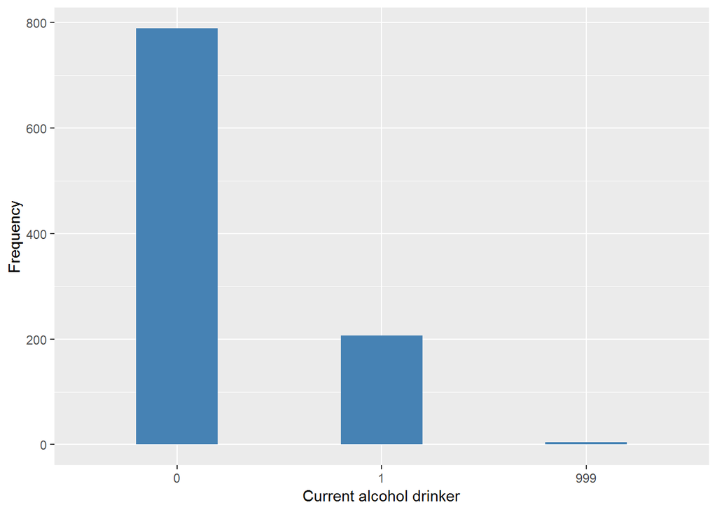

Frequency of alcohol drinking

| Sample size | Missing values |
| --- | --- |
| 1000 | 4 |

Category

|  | 0 | 1 | 2 |
| --- | --- | --- | --- |
| Frequency | 789.0 | 102.0 | 105.0 |
| Percentage | 78.9 | 10.2 | 10.5 |

Type of missing

|  | 991 | 992 | 993 | 994 | 995 | 996 | 997 | 998 | 999 | NA |
| --- | --- | --- | --- | --- | --- | --- | --- | --- | --- | --- |
| Frequency | 0 | 0 | 0 | 0 | 0 | 0 | 0 | 0 | 4.0 | 0 |
| Percentage | 0 | 0 | 0 | 0 | 0 | 0 | 0 | 0 | 0.4 | 0 |

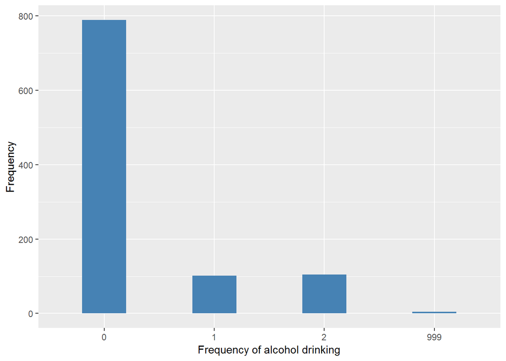

Past drinking

| Sample size | Missing values |
| --- | --- |
| 1000 | 7 |

Category

|  | 0 | 1 |
| --- | --- | --- |
| Frequency | 582.0 | 411.0 |
| Percentage | 58.2 | 41.1 |

Type of missing

|  | 991 | 992 | 993 | 994 | 995 | 996 | 997 | 998 | 999 | NA |
| --- | --- | --- | --- | --- | --- | --- | --- | --- | --- | --- |
| Frequency | 0 | 0 | 0 | 0 | 0 | 0 | 0 | 0 | 7.0 | 0 |
| Percentage | 0 | 0 | 0 | 0 | 0 | 0 | 0 | 0 | 0.7 | 0 |

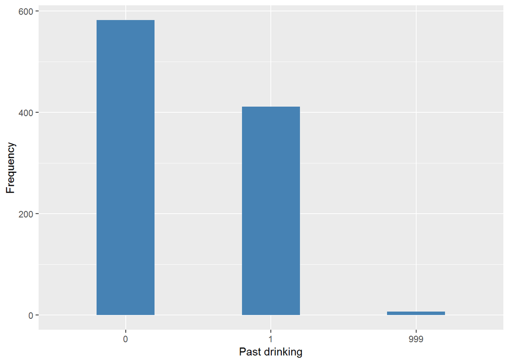

#### 2.10.1.4 Validation

### 2.10.2 Wave 2

#### 2.10.2.1 Study-specific variable description

| **Name** | `f_PALCPAST` |
| --- | --- |
| **Label** | `In the last week how much did you drink` `1 unit = a small glass of beer = a single measure of spirits = 1 glass of wine or sherry` `32 units = 1 bottle of spirits` |
| **Table name** | `1066-RuralMexico-Followup` |
| **Categories** | `continuous` |
| **Missings** | `NA` |
| **Description** |  |

f_PALCPAST

| Sample size | Missing values |
| --- | --- |
| 713 | 3 |

Summary

| Min. | 1st Qu. | Median | Mean | 3rd Qu. | Max. | NA’s |
| --- | --- | --- | --- | --- | --- | --- |
| 0 | 0 | 0 | 0.4761 | 0 | 70 | 3 |

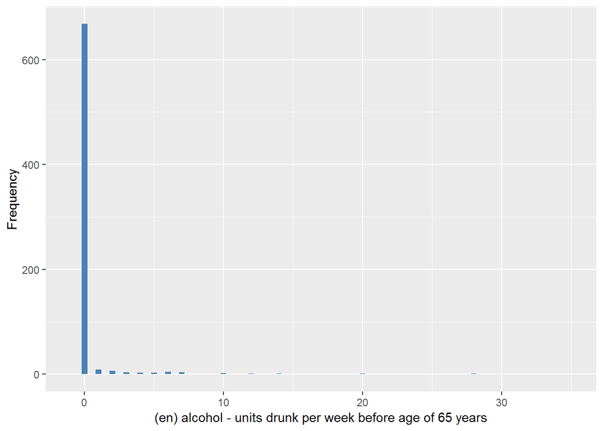

#### 2.10.2.2 Harmonisation algorithm

To compute `current_oh` from the study-specific variable it has to be recoded as follows:

- `f_PALCPAST == 0 into 0`
- `f_PALCPAST > 0 into 1`
- `NA into 999`

To compute `freq_oh` from the study-specific variable it has to be recoded as follows:

- `If f_PALCPAST=0 then 'drinking_frequency'=0`
- `if f_PALCPAST=1 or 2 then 'drinking_frequency'=1`
- `if f_PALCPAST>2 then 'drinking_frequency'=2`

To compute `past_oh` from the study-specific variable it has to be recoded as follows:

- `take from wave 1`

**R script:**

```r
t1066_ds_RM_w2 <- tibble(id = t1066_RM_w2$id)

t1066_ds_RM_w2$freq_oh <- car::recode(t1066_RM_w2$f_PALCPAST, "0 = 0; c(1,2) = 1; 3:hi = 2; NA = 999")
t1066_ds_RM_w2$current_oh <- car::recode(t1066_ds_RM_w2$freq_oh, "2 = 1")

t1066_RM_w2 <- left_join(t1066_RM_w2, t1066_ds_RM_w1, by = "id")
t1066_ds_RM_w2$past_oh <- t1066_RM_w2$past_oh
```

#### 2.10.2.3 Statistics of the new harmonized variable

Current alcohol drinker

| Sample size | Missing values |
| --- | --- |
| 713 | 3 |

Category

|  | 0 | 1 |
| --- | --- | --- |
| Frequency | 668.00 | 42.00 |
| Percentage | 93.69 | 5.89 |

Type of missing

|  | 991 | 992 | 993 | 994 | 995 | 996 | 997 | 998 | 999 | NA |
| --- | --- | --- | --- | --- | --- | --- | --- | --- | --- | --- |
| Frequency | 0 | 0 | 0 | 0 | 0 | 0 | 0 | 0 | 3.00 | 0 |
| Percentage | 0 | 0 | 0 | 0 | 0 | 0 | 0 | 0 | 0.42 | 0 |

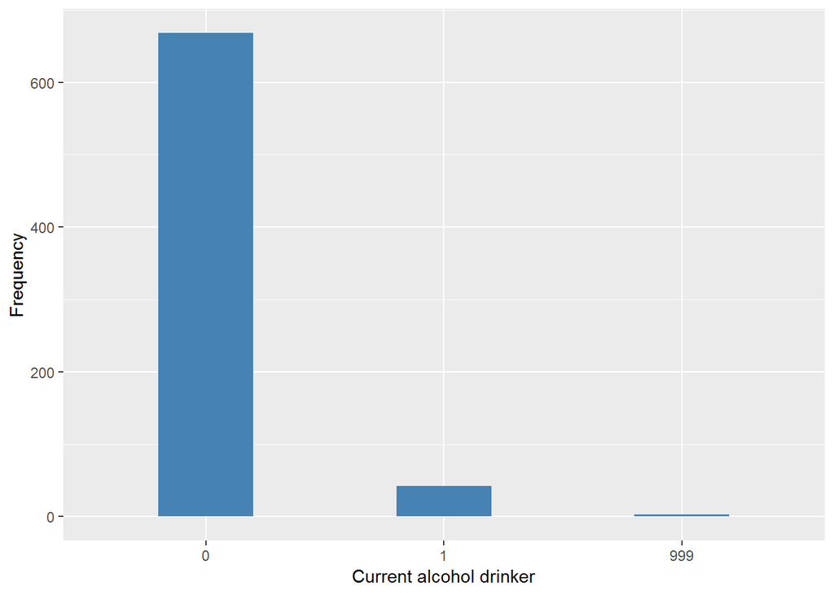

Frequency of alcohol drinking

| Sample size | Missing values |
| --- | --- |
| 713 | 3 |

Category

|  | 0 | 1 | 2 |
| --- | --- | --- | --- |
| Frequency | 668.00 | 15.0 | 27.00 |
| Percentage | 93.69 | 2.1 | 3.79 |

Type of missing

|  | 991 | 992 | 993 | 994 | 995 | 996 | 997 | 998 | 999 | NA |
| --- | --- | --- | --- | --- | --- | --- | --- | --- | --- | --- |
| Frequency | 0 | 0 | 0 | 0 | 0 | 0 | 0 | 0 | 3.00 | 0 |
| Percentage | 0 | 0 | 0 | 0 | 0 | 0 | 0 | 0 | 0.42 | 0 |

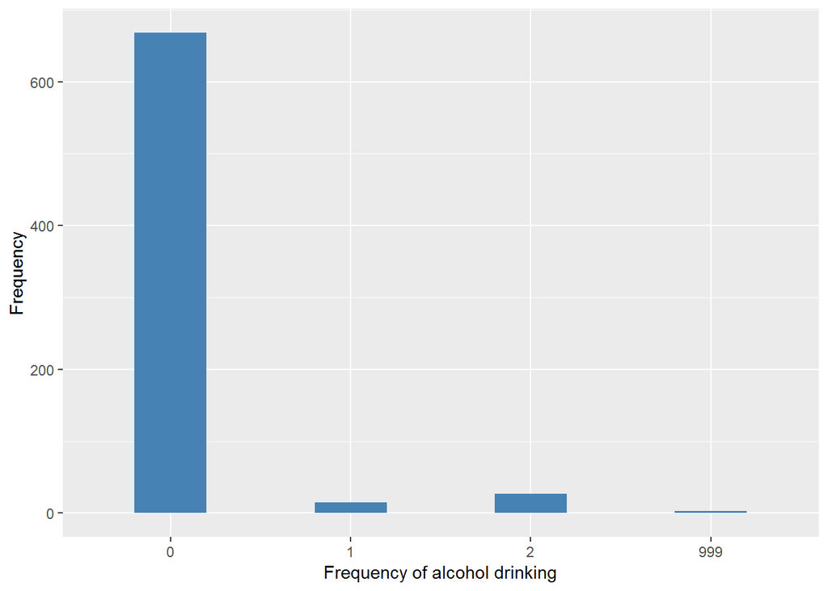

Past drinking

| Sample size | Missing values |
| --- | --- |
| 713 | 2 |

Category

|  | 0 | 1 |
| --- | --- | --- |
| Frequency | 425.00 | 286.00 |
| Percentage | 59.61 | 40.11 |

Type of missing

|  | 991 | 992 | 993 | 994 | 995 | 996 | 997 | 998 | 999 | NA |
| --- | --- | --- | --- | --- | --- | --- | --- | --- | --- | --- |
| Frequency | 0 | 0 | 0 | 0 | 0 | 0 | 0 | 0 | 2.00 | 0 |
| Percentage | 0 | 0 | 0 | 0 | 0 | 0 | 0 | 0 | 0.28 | 0 |

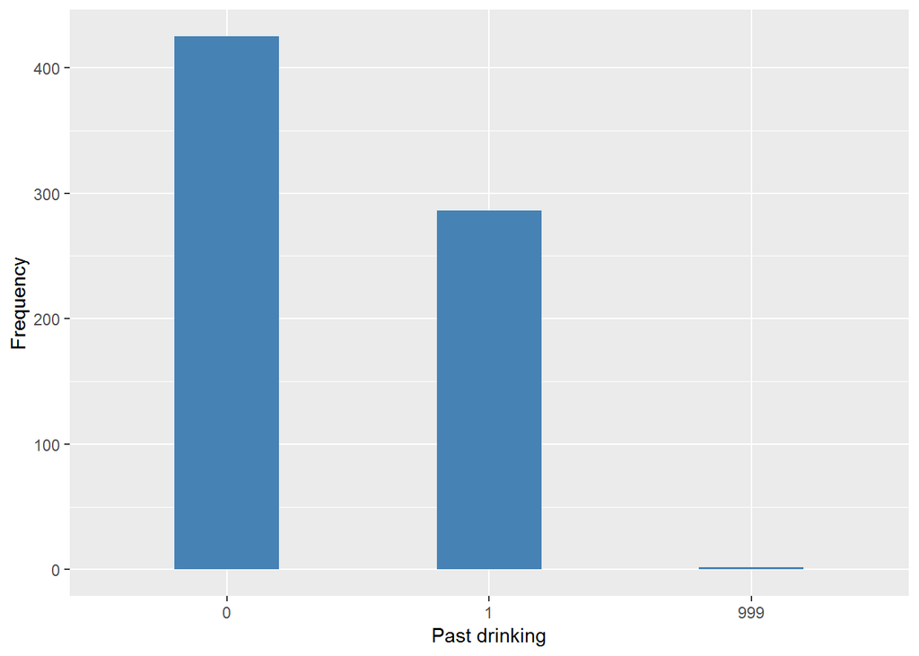

#### 2.10.2.4 Validation

## 2.11 Puerto Rico

### 2.11.1 Wave 1

#### 2.11.1.1 Study-specific variable description

| **Name** | `PALCNOW` | `PALCPAST` |
| --- | --- | --- |
| **Label** | `alcohol - units drunk per week now` `1 unit = a small glass of beer = a single measure of spirits = 1 glass of wine or sherry` `32 units = 1 bottle of spirits` | `alcohol - units drunk per week before age of 65 years` `1 unit = a small glass of beer = a single measure of spirits = 1 glass of wine or sherry` `32 units = 1 bottle of spirits` |
| **Table name** | `1066-PuertoRico-Baseline` | `1066-PuertoRico-Baseline` |
| **Categories** | `continuous` | `continuous` |
| **Missings** | `NA` | `NA` |
| **Description** |  |  |

PALCNOW

| Sample size | Missing values |
| --- | --- |
| 2009 | 10 |

Summary

| Min. | 1st Qu. | Median | Mean | 3rd Qu. | Max. | NA’s |
| --- | --- | --- | --- | --- | --- | --- |
| 0 | 0 | 0 | 1.413 | 0 | 120 | 10 |

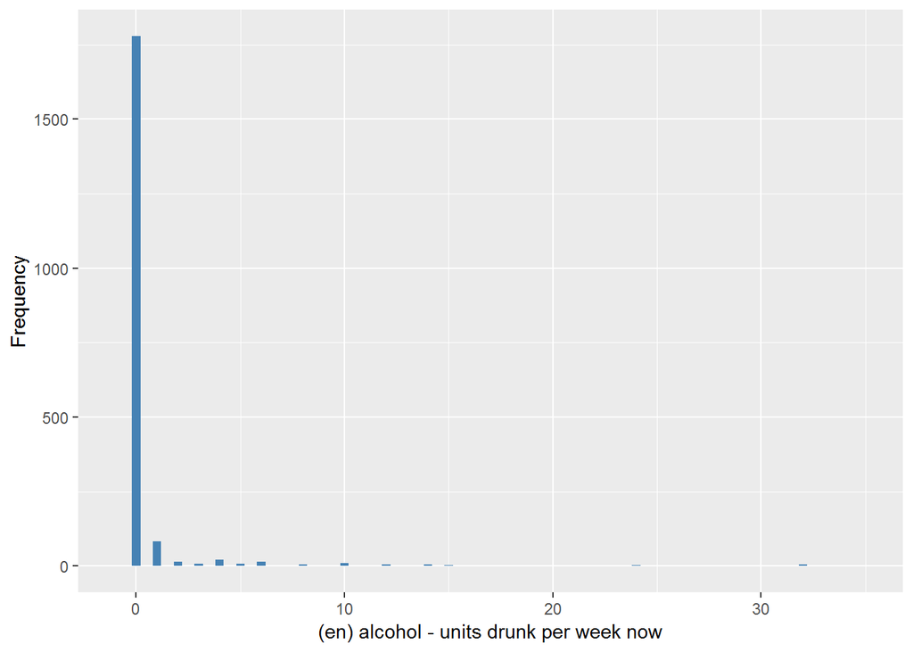

PALCPAST

| Sample size | Missing values |
| --- | --- |
| 2009 | 9 |

Summary

| Min. | 1st Qu. | Median | Mean | 3rd Qu. | Max. | NA’s |
| --- | --- | --- | --- | --- | --- | --- |
| 0 | 0 | 0 | 5.885 | 1 | 400 | 9 |

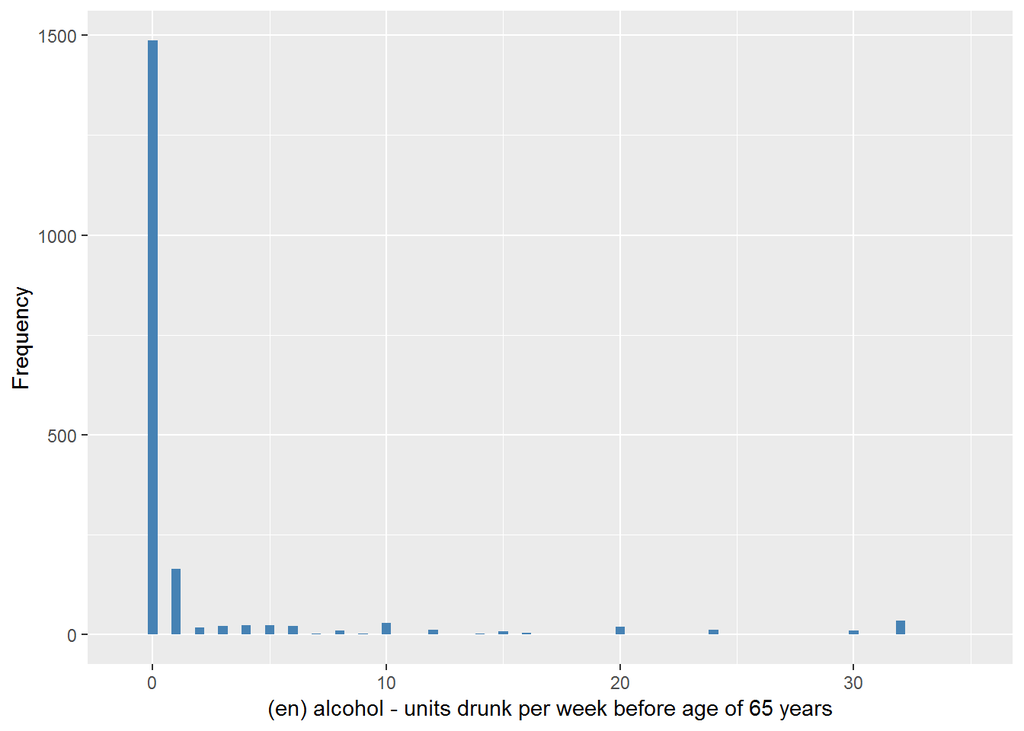

#### 2.11.1.2 Harmonisation algorithm

To compute `current_oh` from the study-specific variable it has to be recoded as follows:

- `PALCNOW == 0 into 0`
- `PALCNOW > 0 into 1`
- `NA into 999`

To compute `freq_oh` from the study-specific variable it has to be recoded as follows:

- `If PALCNOW=0 then 'drinking_frequency'=0`
- `if PALCNOW=1 or 2 then 'drinking_frequency'=1`
- `if PALCNOW>2 then 'drinking_frequency'=2`

To compute `past_oh` from the study-specific variable it has to be recoded as follows:

- `PALCPAST == 0 into 0`
- `PALCPAST > 0 into 1`
- `NA into 999`

**R script:**

```r
t1066_ds_PR_w1 <- tibble(id = t1066_PR_w1$id)
t1066_ds_PR_w1$freq_oh <- car::recode(t1066_PR_w1$PALCNOW, "0 = 0; c(1,2) = 1; 3:hi = 2; NA = 999")
t1066_ds_PR_w1$current_oh <- car::recode(t1066_ds_PR_w1$freq_oh, "2 = 1")
t1066_ds_PR_w1$past_oh <- car::recode(t1066_PR_w1$PALCPAST, "0 = 0; 1:hi = 1; NA = 999")
```

#### 2.11.1.3 Statistics of the new harmonized variable

Current alcohol drinker

| Sample size | Missing values |
| --- | --- |
| 2009 | 10 |

Category

|  | 0 | 1 |
| --- | --- | --- |
| Frequency | 1779.00 | 220.00 |
| Percentage | 88.55 | 10.95 |

Type of missing

|  | 991 | 992 | 993 | 994 | 995 | 996 | 997 | 998 | 999 | NA |
| --- | --- | --- | --- | --- | --- | --- | --- | --- | --- | --- |
| Frequency | 0 | 0 | 0 | 0 | 0 | 0 | 0 | 0 | 10.0 | 0 |
| Percentage | 0 | 0 | 0 | 0 | 0 | 0 | 0 | 0 | 0.5 | 0 |

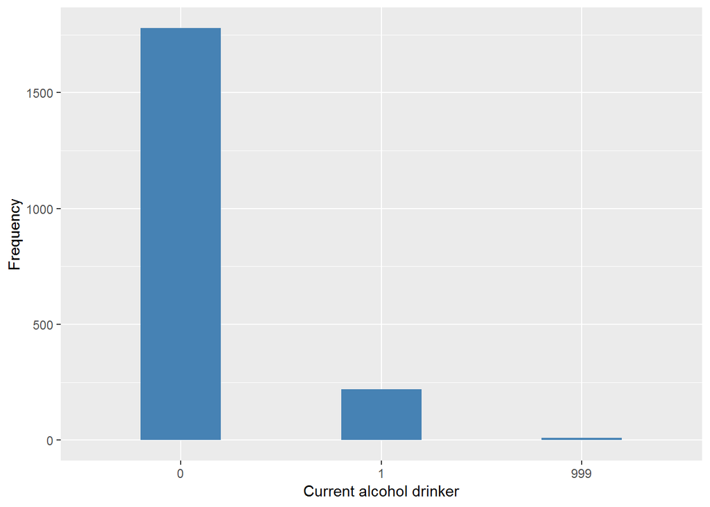

Frequency of alcohol drinking

| Sample size | Missing values |
| --- | --- |
| 2009 | 10 |

Category

|  | 0 | 1 | 2 |
| --- | --- | --- | --- |
| Frequency | 1779.00 | 99.00 | 121.00 |
| Percentage | 88.55 | 4.93 | 6.02 |

Type of missing

|  | 991 | 992 | 993 | 994 | 995 | 996 | 997 | 998 | 999 | NA |
| --- | --- | --- | --- | --- | --- | --- | --- | --- | --- | --- |
| Frequency | 0 | 0 | 0 | 0 | 0 | 0 | 0 | 0 | 10.0 | 0 |
| Percentage | 0 | 0 | 0 | 0 | 0 | 0 | 0 | 0 | 0.5 | 0 |

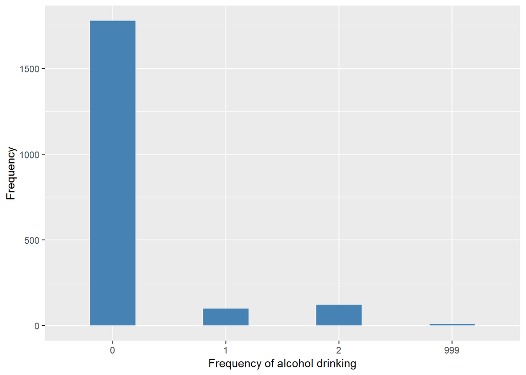

Past drinking

| Sample size | Missing values |
| --- | --- |
| 2009 | 9 |

Category

|  | 0 | 1 |
| --- | --- | --- |
| Frequency | 1487.00 | 513.00 |
| Percentage | 74.02 | 25.54 |

Type of missing

|  | 991 | 992 | 993 | 994 | 995 | 996 | 997 | 998 | 999 | NA |
| --- | --- | --- | --- | --- | --- | --- | --- | --- | --- | --- |
| Frequency | 0 | 0 | 0 | 0 | 0 | 0 | 0 | 0 | 9.00 | 0 |
| Percentage | 0 | 0 | 0 | 0 | 0 | 0 | 0 | 0 | 0.45 | 0 |

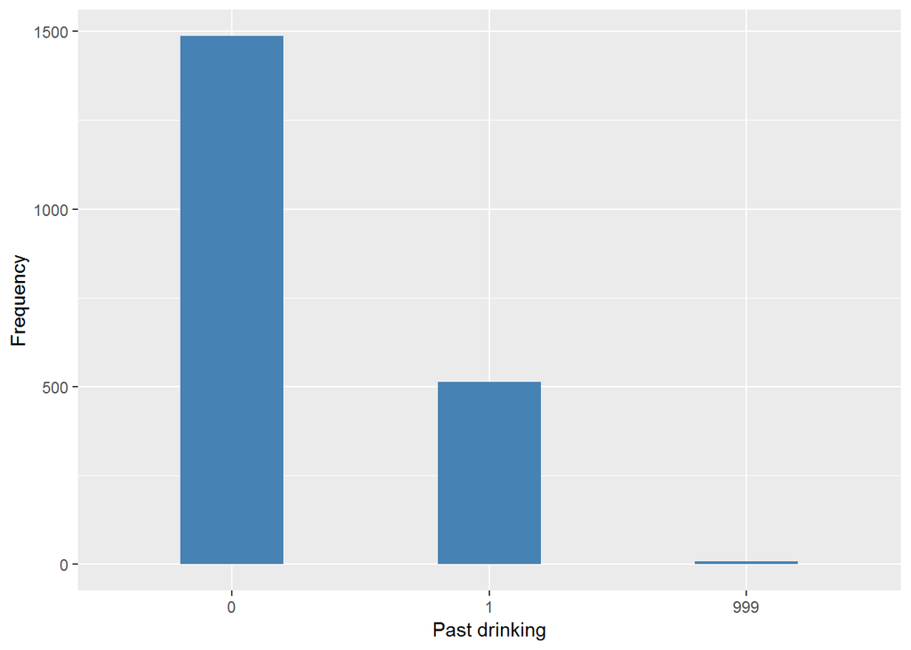

#### 2.11.1.4 Validation

### 2.11.2 Wave 2

#### 2.11.2.1 Study-specific variable description

| **Name** | `f_PALCPAST` |
| --- | --- |
| **Label** | `In the last week how much did you drink` `1 unit = a small glass of beer = a single measure of spirits = 1 glass of wine or sherry` `32 units = 1 bottle of spirits` |
| **Table name** | `1066-PuertoRico-Followup` |
| **Categories** | `continuous` |
| **Missings** | `NA` |
| **Description** |  |

f_PALCPAST

| Sample size | Missing values |
| --- | --- |
| 1265 | 13 |

Summary

| Min. | 1st Qu. | Median | Mean | 3rd Qu. | Max. | NA’s |
| --- | --- | --- | --- | --- | --- | --- |
| 0 | 0 | 0 | 0.996 | 0 | 210 | 13 |

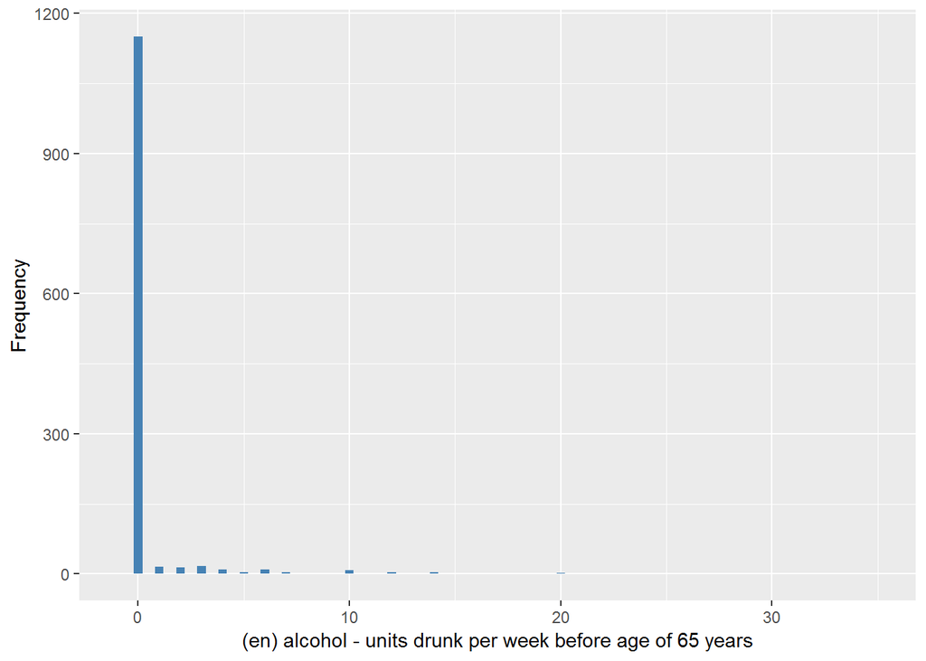

#### 2.11.2.2 Harmonisation algorithm

To compute `current_oh` from the study-specific variable it has to be recoded as follows:

- `f_PALCPAST == 0 into 0`
- `f_PALCPAST > 0 into 1`
- `NA into 999`

To compute `freq_oh` from the study-specific variable it has to be recoded as follows:

- `If f_PALCPAST=0 then 'drinking_frequency'=0`
- `if f_PALCPAST=1 or 2 then 'drinking_frequency'=1`
- `if f_PALCPAST>2 then 'drinking_frequency'=2`

To compute `past_oh` from the study-specific variable it has to be recoded as follows:

- `take from wave 1`

**R script:**

```r
t1066_ds_PR_w2 <- tibble(id = t1066_PR_w2$id)

t1066_ds_PR_w2$freq_oh <- car::recode(t1066_PR_w2$f_PALCPAST, "0 = 0; c(1,2) = 1; 3:hi = 2; NA = 999")
t1066_ds_PR_w2$current_oh <- car::recode(t1066_ds_PR_w2$freq_oh, "2 = 1")

t1066_PR_w2 <- left_join(t1066_PR_w2, t1066_ds_PR_w1, by = "id")
t1066_ds_PR_w2$past_oh <- t1066_PR_w2$past_oh
```

#### 2.11.2.3 Statistics of the new harmonized variable

Current alcohol drinker

| Sample size | Missing values |
| --- | --- |
| 1265 | 13 |

Category

|  | 0 | 1 |
| --- | --- | --- |
| Frequency | 1150.00 | 102.00 |
| Percentage | 90.91 | 8.06 |

Type of missing

|  | 991 | 992 | 993 | 994 | 995 | 996 | 997 | 998 | 999 | NA |
| --- | --- | --- | --- | --- | --- | --- | --- | --- | --- | --- |
| Frequency | 0 | 0 | 0 | 0 | 0 | 0 | 0 | 0 | 13.00 | 0 |
| Percentage | 0 | 0 | 0 | 0 | 0 | 0 | 0 | 0 | 1.03 | 0 |

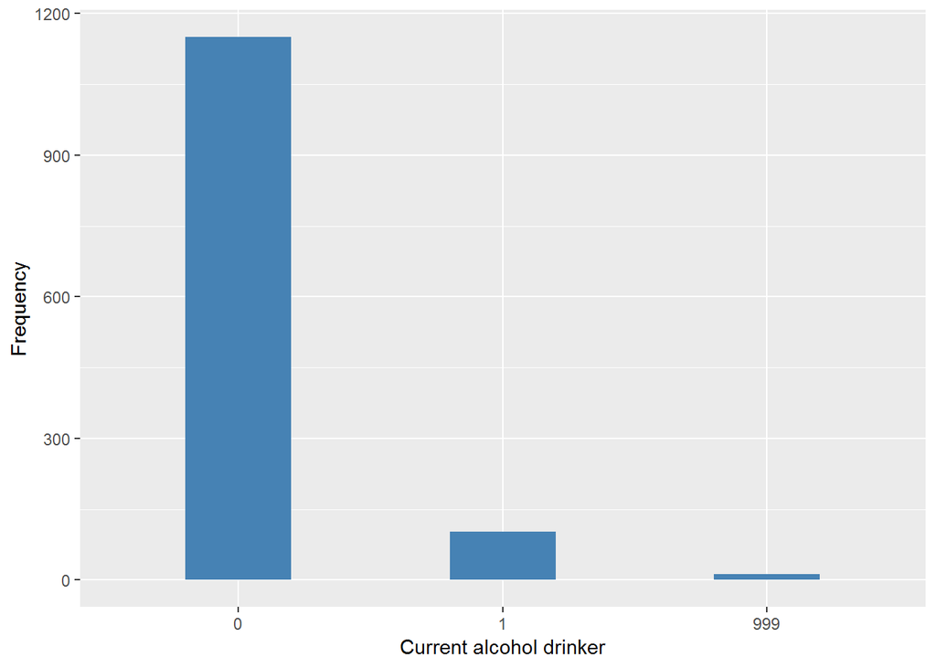

Frequency of alcohol drinking

| Sample size | Missing values |
| --- | --- |
| 1265 | 13 |

Category

|  | 0 | 1 | 2 |
| --- | --- | --- | --- |
| Frequency | 1150.00 | 30.00 | 72.00 |
| Percentage | 90.91 | 2.37 | 5.69 |

Type of missing

|  | 991 | 992 | 993 | 994 | 995 | 996 | 997 | 998 | 999 | NA |
| --- | --- | --- | --- | --- | --- | --- | --- | --- | --- | --- |
| Frequency | 0 | 0 | 0 | 0 | 0 | 0 | 0 | 0 | 13.00 | 0 |
| Percentage | 0 | 0 | 0 | 0 | 0 | 0 | 0 | 0 | 1.03 | 0 |

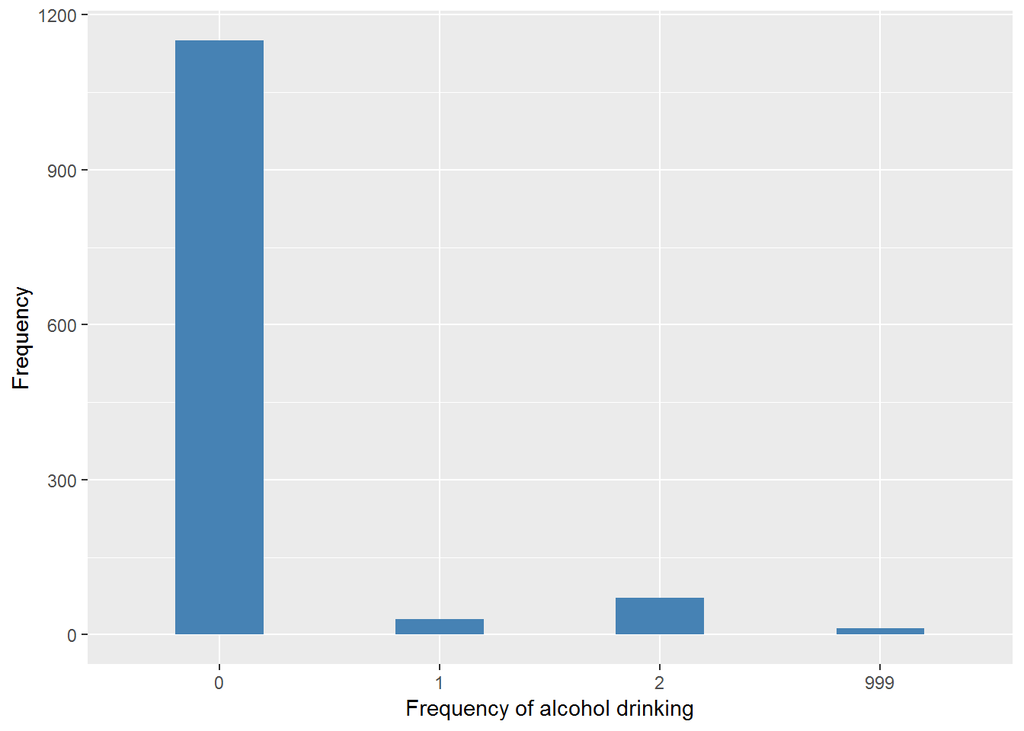

Past drinking

| Sample size | Missing values |
| --- | --- |
| 1265 | 5 |

Category

|  | 0 | 1 |
| --- | --- | --- |
| Frequency | 964.00 | 296.0 |
| Percentage | 76.21 | 23.4 |

Type of missing

|  | 991 | 992 | 993 | 994 | 995 | 996 | 997 | 998 | 999 | NA |
| --- | --- | --- | --- | --- | --- | --- | --- | --- | --- | --- |
| Frequency | 0 | 0 | 0 | 0 | 0 | 0 | 0 | 0 | 5.0 | 0 |
| Percentage | 0 | 0 | 0 | 0 | 0 | 0 | 0 | 0 | 0.4 | 0 |

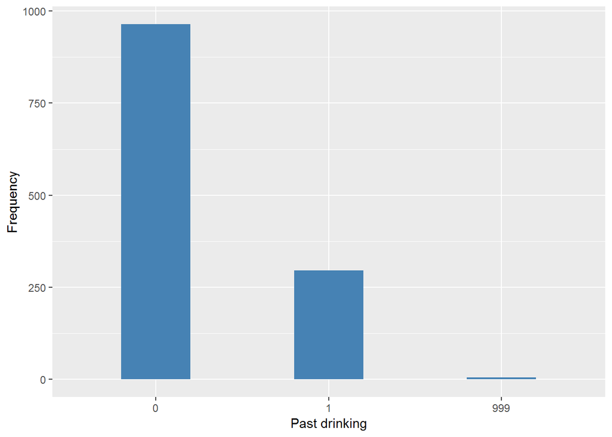

#### 2.11.2.4 Validation

## 2.12 Descriptive statistics of the harmonised variable `current_oh` accross populations and waves

Percentages of categories in each harmonised variable:

```r
tb.hds <- frq(lb.hds[[1]][3])[[1]][, c(1, 2)]
for (i in seq_along(lb.hds)) {
    tb.hds[2 + i] <- frq(lb.hds[[i]][3])[[1]][, 4]
}
tb.hds[13, ] <- c("n", "sample size", length(lb.hds[[1]][[3]]), length(lb.hds[[2]][[3]]),
    length(lb.hds[[3]][[3]]), length(lb.hds[[4]][[3]]), length(lb.hds[[5]][[3]]),
    length(lb.hds[[6]][[3]]), length(lb.hds[[7]][[3]]), length(lb.hds[[8]][[3]]),
    length(lb.hds[[9]][[3]]), length(lb.hds[[10]][[3]]), length(lb.hds[[11]][[3]]))
names(tb.hds) <- c("val", "label", "cuba_w1", "india_w1", "UCh_w1", "RCh_w1",
    "DR_w1", "Ven_w1", "UP_w1", "RP_w1", "UM_w1", "RM_w1", "PR_w1")
kable(tb.hds)
```

| val | label | cuba_w1 | india_w1 | UCh_w1 | RCh_w1 | DR_w1 | Ven_w1 | UP_w1 | RP_w1 | UM_w1 | RM_w1 | PR_w1 |
| --- | --- | --- | --- | --- | --- | --- | --- | --- | --- | --- | --- | --- |
| 0 | No | 85.99 | 81.29 | 96.47 | 84.23 | 81.6 | 41.88 | 92.98 | 92.21 | 82.15 | 78.9 | 88.55 |
| 1 | Yes | 12.34 | 12.28 | 3.53 | 15.77 | 17.65 | 17.25 | 3.62 | 7.07 | 16.55 | 20.7 | 10.95 |
| 991 | CAPI interviewer error | 0 | 0 | 0 | 0 | 0 | 0 | 0 | 0 | 0 | 0 | 0 |
| 992 | Impute | 0 | 0 | 0 | 0 | 0 | 0 | 0 | 0 | 0 | 0 | 0 |
| 993 | Disable to measure | 0 | 0 | 0 | 0 | 0 | 0 | 0 | 0 | 0 | 0 | 0 |
| 994 | Not attempt not done | 0 | 0 | 0 | 0 | 0 | 0 | 0 | 0 | 0 | 0 | 0 |
| 995 | Does not answer | 0 | 0 | 0 | 0 | 0 | 0 | 0 | 0 | 0 | 0 | 0 |
| 996 | Not applicable | 0 | 0 | 0 | 0 | 0 | 0 | 0 | 0 | 0 | 0 | 0 |
| 997 | Refuse | 0 | 0 | 0 | 0 | 0 | 0 | 0 | 0 | 0 | 0 | 0 |
| 998 | Do not know | 0 | 0 | 0 | 0 | 0 | 0 | 0 | 0 | 0 | 0 | 0 |
| 999 | Missing | 1.67 | 6.44 | 0 | 0 | 0.75 | 40.87 | 3.4 | 0.72 | 1.3 | 0.4 | 0.5 |
| NA | NA | 0 | 0 | 0 | 0 | 0 | 0 | 0 | 0 | 0 | 0 | 0 |
| n | sample size | 2813 | 2004 | 1160 | 1002 | 2011 | 1965 | 1381 | 552 | 1003 | 1000 | 2009 |

```r
tf.hds <- frq(lf.hds[[1]][3])[[1]][, c(1, 2)]
for (i in seq_along(lf.hds)) {
    tf.hds[2 + i] <- frq(lf.hds[[i]][3])[[1]][, 4]
}
tf.hds[13, ] <- c("n", "sample size", length(lf.hds[[1]][[3]]), length(lf.hds[[2]][[3]]),
    length(lf.hds[[3]][[3]]), length(lf.hds[[4]][[3]]), length(lf.hds[[5]][[3]]),
    length(lf.hds[[6]][[3]]), length(lf.hds[[7]][[3]]), length(lf.hds[[8]][[3]]),
    length(lf.hds[[9]][[3]]), length(lf.hds[[10]][[3]]))
names(tf.hds) <- c("val", "label", "cuba_w2", "UCh_w2", "RCh_w2", "DR_w2", "Ven_w2",
    "UP_w2", "RP_w2", "UM_w2", "RM_w2", "PR_w2")
kable(tf.hds)
```

| val | label | cuba_w2 | UCh_w2 | RCh_w2 | DR_w2 | Ven_w2 | UP_w2 | RP_w2 | UM_w2 | RM_w2 | PR_w2 |
| --- | --- | --- | --- | --- | --- | --- | --- | --- | --- | --- | --- |
| 0 | No | 93.97 | 91.63 | 79.32 | 91.98 | 85.36 | 92.13 | 97.15 | 88.65 | 93.69 | 90.91 |
| 1 | Yes | 4.29 | 8.37 | 20.39 | 6.02 | 13.76 | 7.75 | 2.85 | 11.08 | 5.89 | 8.06 |
| 991 | CAPI interviewer error | 0 | 0 | 0 | 0 | 0 | 0 | 0 | 0 | 0 | 0 |
| 992 | Impute | 0 | 0 | 0 | 0 | 0 | 0 | 0 | 0 | 0 | 0 |
| 993 | Disable to measure | 0 | 0 | 0 | 0 | 0 | 0 | 0 | 0 | 0 | 0 |
| 994 | Not attempt not done | 0 | 0 | 0 | 0 | 0 | 0 | 0 | 0 | 0 | 0 |
| 995 | Does not answer | 0 | 0 | 0 | 0 | 0 | 0 | 0 | 0 | 0 | 0 |
| 996 | Not applicable | 0 | 0 | 0 | 0 | 0 | 0 | 0 | 0 | 0 | 0 |
| 997 | Refuse | 0 | 0 | 0 | 0 | 0 | 0 | 0 | 0 | 0 | 0 |
| 998 | Do not know | 0 | 0 | 0 | 0 | 0 | 0 | 0 | 0 | 0 | 0 |
| 999 | Missing | 1.74 | 0 | 0.28 | 2.01 | 0.88 | 0.11 | 0 | 0.27 | 0.42 | 1.03 |
| NA | NA | 0 | 0 | 0 | 0 | 0 | 0 | 0 | 0 | 0 | 0 |
| n | sample size | 2007 | 741 | 711 | 1197 | 1257 | 890 | 421 | 749 | 713 | 1265 |

## 2.13 Descriptive statistics of the harmonised variable `freq_oh` accross populations and waves

Percentages of categories in each harmonised variable:

```r
tb.hds <- frq(lb.hds[[1]][2])[[1]][, c(1, 2)]
for (i in seq_along(lb.hds)) {
    tb.hds[2 + i] <- frq(lb.hds[[i]][2])[[1]][, 4]
}
tb.hds[14, ] <- c("n", "sample size", length(lb.hds[[1]][[2]]), length(lb.hds[[2]][[2]]),
    length(lb.hds[[3]][[2]]), length(lb.hds[[4]][[2]]), length(lb.hds[[5]][[2]]),
    length(lb.hds[[6]][[2]]), length(lb.hds[[7]][[2]]), length(lb.hds[[8]][[2]]),
    length(lb.hds[[9]][[2]]), length(lb.hds[[10]][[2]]), length(lb.hds[[11]][[2]]))
names(tb.hds) <- c("val", "label", "cuba_w1", "india_w1", "UCh_w1", "RCh_w1",
    "DR_w1", "Ven_w1", "UP_w1", "RP_w1", "UM_w1", "RM_w1", "PR_w1")
kable(tb.hds)
```

| val | label | cuba_w1 | india_w1 | UCh_w1 | RCh_w1 | DR_w1 | Ven_w1 | UP_w1 | RP_w1 | UM_w1 | RM_w1 | PR_w1 |
| --- | --- | --- | --- | --- | --- | --- | --- | --- | --- | --- | --- | --- |
| 0 | never | 85.99 | 81.29 | 96.47 | 84.23 | 81.6 | 41.88 | 92.98 | 92.21 | 82.15 | 78.9 | 88.55 |
| 1 | rare | 5.19 | 11.08 | 0 | 1.2 | 3.43 | 5.45 | 2.68 | 5.98 | 11.17 | 10.2 | 4.93 |
| 2 | often | 7.15 | 1.2 | 3.53 | 14.57 | 14.22 | 11.81 | 0.94 | 1.09 | 5.38 | 10.5 | 6.02 |
| 991 | CAPI interviewer error | 0 | 0 | 0 | 0 | 0 | 0 | 0 | 0 | 0 | 0 | 0 |
| 992 | Impute | 0 | 0 | 0 | 0 | 0 | 0 | 0 | 0 | 0 | 0 | 0 |
| 993 | Disable to measure | 0 | 0 | 0 | 0 | 0 | 0 | 0 | 0 | 0 | 0 | 0 |
| 994 | Not attempt not done | 0 | 0 | 0 | 0 | 0 | 0 | 0 | 0 | 0 | 0 | 0 |
| 995 | Does not answer | 0 | 0 | 0 | 0 | 0 | 0 | 0 | 0 | 0 | 0 | 0 |
| 996 | Not applicable | 0 | 0 | 0 | 0 | 0 | 0 | 0 | 0 | 0 | 0 | 0 |
| 997 | Refuse | 0 | 0 | 0 | 0 | 0 | 0 | 0 | 0 | 0 | 0 | 0 |
| 998 | Do not know | 0 | 0 | 0 | 0 | 0 | 0 | 0 | 0 | 0 | 0 | 0 |
| 999 | Missing | 1.67 | 6.44 | 0 | 0 | 0.75 | 40.87 | 3.4 | 0.72 | 1.3 | 0.4 | 0.5 |
| NA | NA | 0 | 0 | 0 | 0 | 0 | 0 | 0 | 0 | 0 | 0 | 0 |
| n | sample size | 2813 | 2004 | 1160 | 1002 | 2011 | 1965 | 1381 | 552 | 1003 | 1000 | 2009 |

```r
tf.hds <- frq(lf.hds[[1]][2])[[1]][, c(1, 2)]
for (i in seq_along(lf.hds)) {
    tf.hds[2 + i] <- frq(lf.hds[[i]][2])[[1]][, 4]
}
tf.hds[14, ] <- c("n", "sample size", length(lf.hds[[1]][[2]]), length(lf.hds[[2]][[2]]),
    length(lf.hds[[3]][[2]]), length(lf.hds[[4]][[2]]), length(lf.hds[[5]][[2]]),
    length(lf.hds[[6]][[2]]), length(lf.hds[[7]][[2]]), length(lf.hds[[8]][[2]]),
    length(lf.hds[[9]][[2]]), length(lf.hds[[10]][[2]]))
names(tf.hds) <- c("val", "label", "cuba_w2", "UCh_w2", "RCh_w2", "DR_w2", "Ven_w2",
    "UP_w2", "RP_w2", "UM_w2", "RM_w2", "PR_w2")
kable(tf.hds)
```

| val | label | cuba_w2 | UCh_w2 | RCh_w2 | DR_w2 | Ven_w2 | UP_w2 | RP_w2 | UM_w2 | RM_w2 | PR_w2 |
| --- | --- | --- | --- | --- | --- | --- | --- | --- | --- | --- | --- |
| 0 | never | 93.97 | 91.63 | 79.32 | 91.98 | 85.36 | 92.13 | 97.15 | 88.65 | 93.69 | 90.91 |
| 1 | rare | 2.39 | 1.62 | 5.06 | 2.34 | 5.01 | 4.83 | 0.71 | 7.74 | 2.1 | 2.37 |
| 2 | often | 1.89 | 6.75 | 15.33 | 3.68 | 8.75 | 2.92 | 2.14 | 3.34 | 3.79 | 5.69 |
| 991 | CAPI interviewer error | 0 | 0 | 0 | 0 | 0 | 0 | 0 | 0 | 0 | 0 |
| 992 | Impute | 0 | 0 | 0 | 0 | 0 | 0 | 0 | 0 | 0 | 0 |
| 993 | Disable to measure | 0 | 0 | 0 | 0 | 0 | 0 | 0 | 0 | 0 | 0 |
| 994 | Not attempt not done | 0 | 0 | 0 | 0 | 0 | 0 | 0 | 0 | 0 | 0 |
| 995 | Does not answer | 0 | 0 | 0 | 0 | 0 | 0 | 0 | 0 | 0 | 0 |
| 996 | Not applicable | 0 | 0 | 0 | 0 | 0 | 0 | 0 | 0 | 0 | 0 |
| 997 | Refuse | 0 | 0 | 0 | 0 | 0 | 0 | 0 | 0 | 0 | 0 |
| 998 | Do not know | 0 | 0 | 0 | 0 | 0 | 0 | 0 | 0 | 0 | 0 |
| 999 | Missing | 1.74 | 0 | 0.28 | 2.01 | 0.88 | 0.11 | 0 | 0.27 | 0.42 | 1.03 |
| NA | NA | 0 | 0 | 0 | 0 | 0 | 0 | 0 | 0 | 0 | 0 |
| n | sample size | 2007 | 741 | 711 | 1197 | 1257 | 890 | 421 | 749 | 713 | 1265 |

## 2.14 Descriptive statistics of the harmonised variable `past_oh` accross populations and waves

Percentages of categories in each harmonised variable:

```r
tb.hds <- frq(lb.hds[[1]][4])[[1]][, c(1, 2)]
for (i in seq_along(lb.hds)) {
    tb.hds[2 + i] <- frq(lb.hds[[i]][4])[[1]][, 4]
}
tb.hds[13, ] <- c("n", "sample size", length(lb.hds[[1]][[4]]), length(lb.hds[[2]][[4]]),
    length(lb.hds[[3]][[4]]), length(lb.hds[[4]][[4]]), length(lb.hds[[5]][[4]]),
    length(lb.hds[[6]][[4]]), length(lb.hds[[7]][[4]]), length(lb.hds[[8]][[4]]),
    length(lb.hds[[9]][[4]]), length(lb.hds[[10]][[4]]), length(lb.hds[[11]][[4]]))
names(tb.hds) <- c("val", "label", "cuba_w1", "india_w1", "UCh_w1", "RCh_w1",
    "DR_w1", "Ven_w1", "UP_w1", "RP_w1", "UM_w1", "RM_w1", "PR_w1")
kable(tb.hds)
```

| val | label | cuba_w1 | india_w1 | UCh_w1 | RCh_w1 | DR_w1 | Ven_w1 | UP_w1 | RP_w1 | UM_w1 | RM_w1 | PR_w1 |
| --- | --- | --- | --- | --- | --- | --- | --- | --- | --- | --- | --- | --- |
| 0 | No | 80.16 | 80.19 | 95.52 | 81.44 | 60.17 | 32.93 | 90.22 | 88.77 | 66 | 58.2 | 74.02 |
| 1 | Yes | 18.38 | 16.62 | 4.48 | 18.56 | 38.94 | 27.63 | 7.17 | 10.33 | 32.8 | 41.1 | 25.54 |
| 991 | CAPI interviewer error | 0 | 0 | 0 | 0 | 0 | 0 | 0 | 0 | 0 | 0 | 0 |
| 992 | Impute | 0 | 0 | 0 | 0 | 0 | 0 | 0 | 0 | 0 | 0 | 0 |
| 993 | Disable to measure | 0 | 0 | 0 | 0 | 0 | 0 | 0 | 0 | 0 | 0 | 0 |
| 994 | Not attempt not done | 0 | 0 | 0 | 0 | 0 | 0 | 0 | 0 | 0 | 0 | 0 |
| 995 | Does not answer | 0 | 0 | 0 | 0 | 0 | 0 | 0 | 0 | 0 | 0 | 0 |
| 996 | Not applicable | 0 | 0 | 0 | 0 | 0 | 0 | 0 | 0 | 0 | 0 | 0 |
| 997 | Refuse | 0 | 0 | 0 | 0 | 0 | 0 | 0 | 0 | 0 | 0 | 0 |
| 998 | Do not know | 0 | 0 | 0 | 0 | 0 | 0 | 0 | 0 | 0 | 0 | 0 |
| 999 | Missing | 1.46 | 3.19 | 0 | 0 | 0.9 | 39.44 | 2.61 | 0.91 | 1.2 | 0.7 | 0.45 |
| NA | NA | 0 | 0 | 0 | 0 | 0 | 0 | 0 | 0 | 0 | 0 | 0 |
| n | sample size | 2813 | 2004 | 1160 | 1002 | 2011 | 1965 | 1381 | 552 | 1003 | 1000 | 2009 |

```r
tf.hds <- frq(lf.hds[[1]][4])[[1]][, c(1, 2)]
for (i in seq_along(lf.hds)) {
    tf.hds[2 + i] <- frq(lf.hds[[i]][4])[[1]][, 4]
}
tf.hds[13, ] <- c("n", "sample size", length(lf.hds[[1]][[4]]), length(lf.hds[[2]][[4]]),
    length(lf.hds[[3]][[4]]), length(lf.hds[[4]][[4]]), length(lf.hds[[5]][[4]]),
    length(lf.hds[[6]][[4]]), length(lf.hds[[7]][[4]]), length(lf.hds[[8]][[4]]),
    length(lf.hds[[9]][[4]]), length(lf.hds[[10]][[4]]))
names(tf.hds) <- c("val", "label", "cuba_w2", "UCh_w2", "RCh_w2", "DR_w2", "Ven_w2",
    "UP_w2", "RP_w2", "UM_w2", "RM_w2", "PR_w2")
kable(tf.hds)
```

| val | label | cuba_w2 | UCh_w2 | RCh_w2 | DR_w2 | Ven_w2 | UP_w2 | RP_w2 | UM_w2 | RM_w2 | PR_w2 |
| --- | --- | --- | --- | --- | --- | --- | --- | --- | --- | --- | --- |
| 0 | No | 80.92 | 95.82 | 80.45 | 60.99 | 33.09 | 90.79 | 89.31 | 64.35 | 59.61 | 76.21 |
| 1 | Yes | 17.84 | 4.18 | 19.55 | 38.1 | 25.38 | 6.07 | 9.98 | 34.58 | 40.11 | 23.4 |
| 991 | CAPI interviewer error | 0 | 0 | 0 | 0 | 0 | 0 | 0 | 0 | 0 | 0 |
| 992 | Impute | 0 | 0 | 0 | 0 | 0 | 0 | 0 | 0 | 0 | 0 |
| 993 | Disable to measure | 0 | 0 | 0 | 0 | 0 | 0 | 0 | 0 | 0 | 0 |
| 994 | Not attempt not done | 0 | 0 | 0 | 0 | 0 | 0 | 0 | 0 | 0 | 0 |
| 995 | Does not answer | 0 | 0 | 0 | 0 | 0 | 0 | 0 | 0 | 0 | 0 |
| 996 | Not applicable | 0 | 0 | 0 | 0 | 0 | 0 | 0 | 0 | 0 | 0 |
| 997 | Refuse | 0 | 0 | 0 | 0 | 0 | 0 | 0 | 0 | 0 | 0 |
| 998 | Do not know | 0 | 0 | 0 | 0 | 0 | 0 | 0 | 0 | 0 | 0 |
| 999 | Missing | 1.25 | 0 | 0 | 0.92 | 41.53 | 3.15 | 0.71 | 1.07 | 0.28 | 0.4 |
| NA | NA | 0 | 0 | 0 | 0 | 0 | 0 | 0 | 0 | 0 | 0 |
| n | sample size | 2007 | 741 | 711 | 1197 | 1257 | 890 | 421 | 749 | 713 | 1265 |

# 3 Quality estimation